# NCDB Pituitary Carcinoma 2015

All

Jason Brant

March 09, 2018

**Note: To hide the code from this document, click the button in the upper right corner.**

```r
col.width <- c(37, 10, 1, 1, 3, 1, 2, 1, 2, 1, 1, 1, 1, 1, 1, 8, 2, 2, 2, 4, 4, 1, 4, 1, 1, 1, 3, 2, 2, 8,
               2, 5, 5, 5, 4, 5, 5, 5, 4, 2, 1, 2, 1, 3, 1, 1, 1, 1, 1, 1, 3, 3, 3, 3, 3, 3, 3, 3, 3, 3, 3,
               3, 3, 3, 3, 3, 3, 3, 3, 3, 3, 3, 3, 3, 3, 6, 8, 8, 8, 2, 1, 1, 1, 1, 8, 1, 1, 8, 1, 1, 2,
               2, 5, 2, 5, 3, 1, 3, 1, 8, 8, 2, 8, 2, 8, 2, 2, 1, 8, 1, 1, 1, 1, 1, 8, 1, 2, 2, 2, 2, 2,
               1, 1, 1, 2, 1)
col.names.abr <- c("PUF_CASE_ID", "PUF_FACILITY_ID", "FACILITY_TYPE_CD",  "FACILITY_LOCATION_CD", "AGE", "SEX", "RACE",
                   "SPANISH_HISPANIC_ORIGIN", "INSURANCE_STATUS", "MED_INC_QUAR_00", "NO_HSD_QUAR_00", "UR_CD_03",
                   "MED_INC_QUAR_12", "NO_HSD_QUAR_12", "UR_CD_13", "CROWFLY", "CDCC_TOTAL", "SEQUENCE_NUMBER",
                   "CLASS_OF_CASE", "YEAR_OF_DIAGNOSIS", "PRIMARY_SITE",  "LATERALITY", "HISTOLOGY", "BEHAVIOR",
                   "GRADE", "DIAGNOSTIC_CONFIRMATION", "TUMOR_SIZE", "REGIONAL_NODES_POSITIVE",
                   "REGIONAL_NODES_EXAMINED", "DX_STAGING_PROC_DAYS", "RX_SUMM_DXSTG_PROC", "TNM_CLIN_T",
                   "TNM_CLIN_N", "TNM_CLIN_M", "TNM_CLIN_STAGE_GROUP", "TNM_PATH_T", "TNM_PATH_N", "TNM_PATH_M",
                   "TNM_PATH_STAGE_GROUP", "TNM_EDITION_NUMBER", "ANALYTIC_STAGE_GROUP", "CS_METS_AT_DX",
                   "CS_METS_EVAL", "CS_EXTENSION", "CS_TUMOR_SIZEEXT_EVAL", "CS_METS_DX_BONE",
                   "CS_METS_DX_BRAIN", "CS_METS_DX_LIVER", "CS_METS_DX_LUNG", "LYMPH_VASCULAR_INVASION",
                   "CS_SITESPECIFIC_FACTOR_1", "CS_SITESPECIFIC_FACTOR_2", "CS_SITESPECIFIC_FACTOR_3",
                   "CS_SITESPECIFIC_FACTOR_4", "CS_SITESPECIFIC_FACTOR_5", "CS_SITESPECIFIC_FACTOR_6",
                   "CS_SITESPECIFIC_FACTOR_7", "CS_SITESPECIFIC_FACTOR_8", "CS_SITESPECIFIC_FACTOR_9",
                   "CS_SITESPECIFIC_FACTOR_10", "CS_SITESPECIFIC_FACTOR_11", "CS_SITESPECIFIC_FACTOR_12",
                   "CS_SITESPECIFIC_FACTOR_13", "CS_SITESPECIFIC_FACTOR_14", "CS_SITESPECIFIC_FACTOR_15",
                   "CS_SITESPECIFIC_FACTOR_16", "CS_SITESPECIFIC_FACTOR_17", "CS_SITESPECIFIC_FACTOR_18",
                   "CS_SITESPECIFIC_FACTOR_19", "CS_SITESPECIFIC_FACTOR_20", "CS_SITESPECIFIC_FACTOR_21",
                   "CS_SITESPECIFIC_FACTOR_22", "CS_SITESPECIFIC_FACTOR_23", "CS_SITESPECIFIC_FACTOR_24",
                   "CS_SITESPECIFIC_FACTOR_25", "CS_VERSION_LATEST", "DX_RX_STARTED_DAYS",
                   "DX_SURG_STARTED_DAYS", "DX_DEFSURG_STARTED_DAYS", "RX_SUMM_SURG_PRIM_SITE",
                   "RX_HOSP_SURG_APPR_2010", "RX_SUMM_SURGICAL_MARGINS", "RX_SUMM_SCOPE_REG_LN_SUR",
                   "RX_SUMM_SURG_OTH_REGDIS", "SURG_DISCHARGE_DAYS", "READM_HOSP_30_DAYS",
                   "REASON_FOR_NO_SURGERY", "DX_RAD_STARTED_DAYS", "RX_SUMM_RADIATION", "RAD_LOCATION_OF_RX",
                   "RAD_TREAT_VOL", "RAD_REGIONAL_RX_MODALITY", "RAD_REGIONAL_DOSE_CGY",
                   "RAD_BOOST_RX_MODALITY", "RAD_BOOST_DOSE_CGY", "RAD_NUM_TREAT_VOL",
                   "RX_SUMM_SURGRAD_SEQ", "RAD_ELAPSED_RX_DAYS", "REASON_FOR_NO_RADIATION",
                   "DX_SYSTEMIC_STARTED_DAYS", "DX_CHEMO_STARTED_DAYS", "RX_SUMM_CHEMO",
                   "DX_HORMONE_STARTED_DAYS", "RX_SUMM_HORMONE", "DX_IMMUNO_STARTED_DAYS",
                   "RX_SUMM_IMMUNOTHERAPY", "RX_SUMM_TRNSPLNT_ENDO", "RX_SUMM_SYSTEMIC_SUR_SEQ",
                   "DX_OTHER_STARTED_DAYS", "RX_SUMM_OTHER", "PALLIATIVE_CARE", "RX_SUMM_TREATMENT_STATUS",
                   "PUF_30_DAY_MORT_CD", "PUF_90_DAY_MORT_CD", "DX_LASTCONTACT_DEATH_MONTHS",
                   "PUF_VITAL_STATUS", "RX_HOSP_SURG_PRIM_SITE", "RX_HOSP_CHEMO", "RX_HOSP_IMMUNOTHERAPY",
                   "RX_HOSP_HORMONE", "RX_HOSP_OTHER", "PUF_MULT_SOURCE", "REFERENCE_DATE_FLAG",
                   "RX_SUMM_SCOPE_REG_LN_2012", "RX_HOSP_DXSTG_PROC", "PALLIATIVE_CARE_HOSP")
#Read in data for each subsite
bone.joint <- read_fwf('I:/Brant/Research/NCDB/Data/Data_2017/NCDB_PUF_DATA_Nov-07-2017/NCDBPUF_BoneJont.3.2015.0.dat',
                       fwf_widths(col.width, col_names = col.names.abr),
                       col_types = cols(.default = col_character()))
brain <- read_fwf('I:/Brant/Research/NCDB/Data/Data_2017/NCDB_PUF_DATA_Nov-07-2017/NCDBPUF_Brain.3.2015.0.dat',
                       fwf_widths(col.width, col_names = col.names.abr),
                       col_types = cols(.default = col_character()))
cns <- read_fwf('I:/Brant/Research/NCDB/Data/Data_2017/NCDB_PUF_DATA_Nov-07-2017/NCDBPUF_CNS.3.2015.0.dat',
                       fwf_widths(col.width, col_names = col.names.abr),
                       col_types = cols(.default = col_character()))
gum.ot.mth <- read_fwf('I:/Brant/Research/NCDB/Data/Data_2017/NCDB_PUF_DATA_Nov-07-2017/NCDBPUF_GumOtMth.3.2015.0.dat',
                       fwf_widths(col.width, col_names = col.names.abr),
                       col_types = cols(.default = col_character()))
hypophar <- read_fwf('I:/Brant/Research/NCDB/Data/Data_2017/NCDB_PUF_DATA_Nov-07-2017/NCDBPUF_Hypophar.3.2015.0.dat',
                       fwf_widths(col.width, col_names = col.names.abr),
                       col_types = cols(.default = col_character()))
larynx <- read_fwf('I:/Brant/Research/NCDB/Data/Data_2017/NCDB_PUF_DATA_Nov-07-2017/NCDBPUF_Larynx.3.2015.0.dat',
                       fwf_widths(col.width, col_names = col.names.abr),
                       col_types = cols(.default = col_character()))
lip <- read_fwf('I:/Brant/Research/NCDB/Data/Data_2017/NCDB_PUF_DATA_Nov-07-2017/NCDBPUF_Lip.3.2015.0.dat',
                       fwf_widths(col.width, col_names = col.names.abr),
                       col_types = cols(.default = col_character()))
melanoma <- read_fwf('I:/Brant/Research/NCDB/Data/Data_2017/NCDB_PUF_DATA_Nov-07-2017/NCDBPUF_Melanoma.3.2015.0.dat',
                       fwf_widths(col.width, col_names = col.names.abr),
                       col_types = cols(.default = col_character()))
fom <- read_fwf('I:/Brant/Research/NCDB/Data/Data_2017/NCDB_PUF_DATA_Nov-07-2017/NCDBPUF_MouthFlr.3.2015.0.dat',
                       fwf_widths(col.width, col_names = col.names.abr),
                       col_types = cols(.default = col_character()))
nasal <- read_fwf('I:/Brant/Research/NCDB/Data/Data_2017/NCDB_PUF_DATA_Nov-07-2017/NCDBPUF_Nasal.3.2015.0.dat',
                       fwf_widths(col.width, col_names = col.names.abr),
                       col_types = cols(.default = col_character()))
nasophar <- read_fwf('I:/Brant/Research/NCDB/Data/Data_2017/NCDB_PUF_DATA_Nov-07-2017/NCDBPUF_Nasophar.3.2015.0.dat',
                       fwf_widths(col.width, col_names = col.names.abr),
                       col_types = cols(.default = col_character()))
orophar <- read_fwf('I:/Brant/Research/NCDB/Data/Data_2017/NCDB_PUF_DATA_Nov-07-2017/NCDBPUF_Orophary.3.2015.0.dat',
                       fwf_widths(col.width, col_names = col.names.abr),
                       col_types = cols(.default = col_character()))
oth.endo <- read_fwf('I:/Brant/Research/NCDB/Data/Data_2017/NCDB_PUF_DATA_Nov-07-2017/NCDBPUF_OtEndocr.3.2015.0.dat',
                       fwf_widths(col.width, col_names = col.names.abr),
                       col_types = cols(.default = col_character()))
skin <- read_fwf('I:/Brant/Research/NCDB/Data/Data_2017/NCDB_PUF_DATA_Nov-07-2017/NCDBPUF_OtSkin.3.2015.0.dat',
                       fwf_widths(col.width, col_names = col.names.abr),
                       col_types = cols(.default = col_character()))
pharynx <- read_fwf('I:/Brant/Research/NCDB/Data/Data_2017/NCDB_PUF_DATA_Nov-07-2017/NCDBPUF_Pharynx.3.2015.0.dat',
                       fwf_widths(col.width, col_names = col.names.abr),
                       col_types = cols(.default = col_character()))
saliv.gland <- read_fwf('I:/Brant/Research/NCDB/Data/Data_2017/NCDB_PUF_DATA_Nov-07-2017/NCDBPUF_SalivGld.3.2015.0.dat',
                       fwf_widths(col.width, col_names = col.names.abr),
                       col_types = cols(.default = col_character()))
thyroid <- read_fwf('I:/Brant/Research/NCDB/Data/Data_2017/NCDB_PUF_DATA_Nov-07-2017/NCDBPUF_Thyroid.3.2015.0.dat',
                       fwf_widths(col.width, col_names = col.names.abr),
                       col_types = cols(.default = col_character()))
tongue <- read_fwf('I:/Brant/Research/NCDB/Data/Data_2017/NCDB_PUF_DATA_Nov-07-2017/NCDBPUF_Tongue.3.2015.0.dat',
                       fwf_widths(col.width, col_names = col.names.abr),
                       col_types = cols(.default = col_character()))
tonsil <- read_fwf('I:/Brant/Research/NCDB/Data/Data_2017/NCDB_PUF_DATA_Nov-07-2017/NCDBPUF_Tonsil.3.2015.0.dat',
                       fwf_widths(col.width, col_names = col.names.abr),
                       col_types = cols(.default = col_character()))
trach.med <- read_fwf('I:/Brant/Research/NCDB/Data/Data_2017/NCDB_PUF_DATA_Nov-07-2017/NCDBPUF_TrachMed.3.2015.0.dat',
                       fwf_widths(col.width, col_names = col.names.abr),
                       col_types = cols(.default = col_character()))
#Combine data for all subsites
dat <- bind_rows(bone.joint, brain, cns, gum.ot.mth, hypophar, larynx, lip, melanoma, fom, nasal, nasophar, orophar,
                 oth.endo, skin, pharynx, saliv.gland, thyroid, tongue, tonsil, trach.med)
rm(bone.joint, brain, cns, gum.ot.mth, hypophar, larynx, lip, melanoma, fom, nasal, nasophar, orophar,
                 oth.endo, skin, pharynx, saliv.gland, thyroid, tongue, tonsil, trach.med)
prim_site_text <- data_frame(PRIMARY_SITE = c("C030", "C031", "C062", "C039", "C050", "C051", "C052", "C058", "C059", "C068",
               "C069", "C060", "C061", "C129", "C130", "C131", "C132", "C138", "C139", "C320",
               "C321", "C322", "C323", "C328", "C329", "C000", "C003", "C001", "C004", "C006",
               "C002", "C005", "C008", "C009", "C440", "C442", "C443", "C444", "C445", "C446",
               "C447", "C448", "C449", "C441", "C040", "C041", "C048", "C049", "C300", "C301",
               "C310", "C311", "C312", "C313", "C318", "C319", "C110", "C111", "C112", "C113",
               "C118", "C119", "C090", "C091", "C098", "C099", "C100", "C102", "C103", "C104",
               "C108", "C109", "C101", "C140", "C142", "C148", "C079", "C080", "C081", "C088",
               "C089", "C739", "C019", "C024", "C020", "C021", "C022", "C023", "C028", "C029"),
               SITE_TEXT = c("C03.0: Gum, upper", "C03.1 Gum, lower", "C06.2 Retromolar area", "C03.9 Gum, NOS",
               "C05.0 Hard Palate", "C05.1 Soft Palate", "C05.2 Uvula", "C05.8 Overlapping lesion of palate",
               "C05.9 Palate NOS", "C06.8 Overlapping lesion of other an unspecified parts of mouth",
               "C06.9 Mouth, NOS", "C06.0 Buccal mucosa", "C06.1 Vestibule of mouth", "C12.9  Pyriform sinus",
               "C13.0  Postcricoid region", "C13.1  Hypopharyngeal aspect of aryepiglottic fold",
               "C13.2  Posterior wall of hypopharynx", "C13.8  Overlapping lesion of hypopharynx",
               "C13.9  Hypopharynx, NOS (laryngopharynx)", "C32.0  Glottis", "C32.1  Supraglottis",
               "C32.2  Subglottis", "C32.3  Laryngeal cartilage", "C32.8  Overlapping lesion of larynx",
               "C32.9  Larynx, NOS", "C00.0  External upper lip (vermilion)", "C00.3  Mucosa of upper lip",
               "C00.1  External lower lip (vermilion)", "C00.4  Mucosa of lower lip", "C00.6  Commissure of lip",
               "C00.2  External lip, NOS (vermilion)", "C00.5  Mucosa of lip, NOS", "C00.8  Overlapping lesion of lip",
               "C00.9  Lip, NOS (excludes skin of lip C44.0)", "C44.0  Skin of lip, NOS", "C44.2  External ear",
               "C44.3  Skin of other and unspecified parts of face", "C44.4  Skin of scalp and neck",
               "C44.5  Skin of trunk", "C44.6  Skin of upper limb and shoulder", "C44.7  Skin of lower limb and hip",
               "C44.8  Overlapping lesion of skin", "C44.9  Skin, NOS", "C44.1 Eyelid",
```

```r
               "C04.0  Anterior floor of mouth", "C04.1  Lateral floor of mouth", "C04.8  Overlapping lesion of floor of mouth",
               "C04.9  Floor of mouth, NOS", "C30.0  Nasal cavity (excluding nose, NOS C76.0)", "C30.1  Middle ear",
               "C31.0  Maxillary sinus", "C31.1  Ethmoid sinus", "C31.2  Frontal sinus", "C31.3  Sphenoid sinus",
               "C31.8  Overlapping lesion of accessory sinuses", "C31.9  Accessory sinus, NOS",
               "C11.0  Superior wall of nasopharynx", "C11.1  Posterior wall of nasopharynx (excluding pharyngeal tonsil)",
               "C11.2  Lateral wall of nasopharynx", "C11.3  Anterior wall of nasopharynx",
               "C11.8  Overlapping lesion of nasopharynx", "C11.9  Nasopharynx, NOS", "C09.0  Tonsillar fossa",
               "C09.1  Tonsillar pillar", "C09.8  Overlapping lesion of tonsil",
               "C09.9  Tonsil, NOS (excluding lingual tonsil C02.4)", "C10.0  Vallecula",
               "C10.2  Lateral wall of oropharynx", "C10.3  Posterior wall of oropharynx",
               "C10.4  Branchial cleft (site of neoplasm)", "C10.8  Overlapping lesion of oropharynx",
               "C10.9  Oropharynx, NOS", "C10.1  Anterior surface of epiglottis", "C14.0  Pharynx, NOS",
               "C14.2  Waldeyer ring", "C14.8  Overlapping lesion of lip, oral cavity", "C07.9  Parotid gland",
               "C08.0  Submandibular gland", "C08.1  Sublingual gland", "C08.8  Overlapping lesion of major salivary glands",
               "C08.9  Major salivary gland, NOS", "C73.9  Thyroid gland", "C01.9  Base of tongue, NOS",
               "C02.4  Lingual tonsil", "C02.0  Dorsal surface of tongue, NOS", "C02.1  Border of tongue (Tip)",
               "C02.2  Ventral surface of tongue, NOS", "C02.3  Anterior 2/3 of tongue, NOS",
               "C02.8  Overlapping lesion of tongue", "C02.9  Tongue, NOS"),
               CS_GROUP = c("gum_upper", "gum_lower", "gum_lower", "gum_nos", "hard_palate", "soft_palate",
             "soft_palate", "other_mouth", "other_mouth", "other_mouth", "other_mouth",
             "buccal", "buccal", "hypopharynx", "hypopharynx", "hypopharynx", "hypopharynx",
             "hypopharynx", "hypopharynx", "glottis", "supraglot", "subglot", "lx_oth",
             "lx_oth", "lx_oth", "up_lip", "up_lip", "low_lip", "low_lip", "low_lip",
             "lip_oth", "lip_oth", "lip_oth", "lip_oth", "skin", "skin", "skin", "skin",
             "skin", "skin", "skin", "skin", "skin", "eyelid", "fom", "fom", "fom", "fom",
             "nasal_cavity", "mid_ear", "max_sin", "eth_sin", "oth_sin", "oth_sin",
             "oth_sin", "oth_sin", "np", "np", "np", "np", "np", "np", "op",
             "op", "op", "op", "op", "op", "op", "op", "op", "op", "ant_epi",
             "oth_phary", "oth_phary", "oth_phary", "parotid", "smglnd",
             "glnd_oth", "glnd_oth", "glnd_oth", "thyroid", "bot_lt",
             "bot_lt", "tongue_oth", "tongue_oth", "tongue_oth", "tongue_oth",
             "tongue_oth", "tongue_oth"))
dat <- merge(dat, prim_site_text, by = "PRIMARY_SITE", all.x = TRUE)
rm(prim_site_text)
fact_vars <- c("PRIMARY_SITE", "FACILITY_TYPE_CD", "FACILITY_LOCATION_CD", "SEX", "RACE", "SPANISH_HISPANIC_ORIGIN",
               "INSURANCE_STATUS", "MED_INC_QUAR_00", "NO_HSD_QUAR_00", "UR_CD_03", "MED_INC_QUAR_12",
               "NO_HSD_QUAR_12", "UR_CD_13", "CDCC_TOTAL", "SEQUENCE_NUMBER", "CLASS_OF_CASE",
               "YEAR_OF_DIAGNOSIS", "LATERALITY", "HISTOLOGY", "BEHAVIOR",
               "GRADE", "DIAGNOSTIC_CONFIRMATION", "REGIONAL_NODES_POSITIVE", "REGIONAL_NODES_EXAMINED",
               "RX_SUMM_DXSTG_PROC", "TNM_CLIN_T",
               "TNM_CLIN_N", "TNM_CLIN_M", "TNM_CLIN_STAGE_GROUP", "TNM_PATH_T", "TNM_PATH_N",
               "TNM_PATH_M", "TNM_PATH_STAGE_GROUP", "TNM_EDITION_NUMBER", "ANALYTIC_STAGE_GROUP",
               "CS_METS_AT_DX", "CS_METS_EVAL", "CS_EXTENSION", "CS_TUMOR_SIZEEXT_EVAL", "CS_METS_DX_BONE",
               "CS_METS_DX_BRAIN", "CS_METS_DX_LIVER", "CS_METS_DX_LUNG", "LYMPH_VASCULAR_INVASION",
               "CS_VERSION_LATEST", "RX_SUMM_SURG_PRIM_SITE", "RX_HOSP_SURG_APPR_2010", "RX_SUMM_SURGICAL_MARGINS",
               "RX_SUMM_SCOPE_REG_LN_SUR", "RX_SUMM_SURG_OTH_REGDIS", "READM_HOSP_30_DAYS", "REASON_FOR_NO_SURGERY",
               "RX_SUMM_RADIATION",
               "RAD_LOCATION_OF_RX", "RAD_TREAT_VOL", "RAD_REGIONAL_RX_MODALITY", "RAD_BOOST_RX_MODALITY",
               "RX_SUMM_SURGRAD_SEQ", "REASON_FOR_NO_RADIATION", "RX_SUMM_CHEMO", "RX_SUMM_HORMONE",
               "RX_SUMM_IMMUNOTHERAPY", "RX_SUMM_TRNSPLNT_ENDO", "RX_SUMM_SYSTEMIC_SUR_SEQ",
               "RX_SUMM_OTHER", "PALLIATIVE_CARE", "RX_SUMM_TREATMENT_STATUS", "PUF_30_DAY_MORT_CD",
               "PUF_90_DAY_MORT_CD", "RX_HOSP_SURG_PRIM_SITE", "RX_HOSP_CHEMO", "RX_HOSP_IMMUNOTHERAPY",
               "RX_HOSP_HORMONE", "RX_HOSP_OTHER", "PUF_MULT_SOURCE", "REFERENCE_DATE_FLAG",
               "RX_SUMM_SCOPE_REG_LN_2012",   'RX_HOSP_DXSTG_PROC', 'PALLIATIVE_CARE_HOSP')
dat[fact_vars] <- lapply(dat[fact_vars], as.character)
dat[fact_vars] <- lapply(dat[fact_vars], as.factor)
num_vars <- c("AGE", "CROWFLY", "TUMOR_SIZE", "DX_STAGING_PROC_DAYS", "DX_RX_STARTED_DAYS", "DX_SURG_STARTED_DAYS",
              "DX_DEFSURG_STARTED_DAYS", "SURG_DISCHARGE_DAYS", "DX_RAD_STARTED_DAYS",  "RAD_REGIONAL_DOSE_CGY",
              "RAD_BOOST_DOSE_CGY", "RAD_ELAPSED_RX_DAYS", "DX_SYSTEMIC_STARTED_DAYS", "DX_CHEMO_STARTED_DAYS",
              "DX_HORMONE_STARTED_DAYS", "DX_OTHER_STARTED_DAYS", "DX_LASTCONTACT_DEATH_MONTHS",
              "RAD_NUM_TREAT_VOL")
dat[num_vars] <- lapply(dat[num_vars], as.numeric)
```

```r
p_table <- function(tab_data, ...) {
  tab_data_2 <- deparse(substitute(tab_data))

  table_p <- do.call(CreateTableOne,
                     list(data = as.name(tab_data_2), includeNA = TRUE, ...))
  table_p_out <- print(table_p,
                       showAllLevels = TRUE,
                       printToggle = FALSE)
  kable(table_p_out,
        align = "c")
}
```

# Data

```r
site_code <- c("C751")
histo_code <- c("8140", "8146", "8246", "8260", "8270", "8271", "8272", "8280", "8281", "8290", "8300", "8323")
behavior_code <- c("All")
data <- dat %>%
        #filter(BEHAVIOR %in% behavior_code) %>%
        filter(PRIMARY_SITE %in% site_code) %>%
        filter(HISTOLOGY %in% histo_code) %>%
        filter(is.na(PUF_VITAL_STATUS) == FALSE) %>%
        filter(is.na(DX_LASTCONTACT_DEATH_MONTHS) == FALSE)
```

1. Site codes: C751
2. Histology codes: 8140, 8146, 8246, 8260, 8270, 8271, 8272, 8280, 8281, 8290, 8300, 8323
3. Behavior codes: All

Patients were excluded if they didn’t have values for either follow up or vital status.

Patients were excluded if they had surgery to a distant site using `RX_SUMM_SURG_OTH_REGDIS`. This was done to avoid confounding of different surgical procedures. We are only interested in surgery at the primary site. These distant site surgeries were being counted in the surgery/radiation sequence and thus to simplify analysis they were removed.

```r
data %>%
        CreateTableOne(data = .,
                     vars = c("RX_SUMM_SURG_OTH_REGDIS"),
                     includeNA = TRUE) %>%
        print(.,
              showAllLevels = TRUE)
```

```
                              level Overall
  n                                 80491
  RX_SUMM_SURG_OTH_REGDIS (%) 0     77338 (96.1)
                              1       137 ( 0.2)
                              2       139 ( 0.2)
                              3         6 ( 0.0)
                              4        23 ( 0.0)
                              5         6 ( 0.0)
                              9      2842 ( 3.5)
```

```r
data <- data %>%
        filter(RX_SUMM_SURG_OTH_REGDIS == "0")
```

# Limit to patients with mets at diagnosis

|  | level | Overall |
| --- | --- | --- |
| n |  | 92 |
| CS_METS_AT_DX (%) | Lymph Nodes | 27 (29.3) |
|  | Mets not LN | 26 (28.3) |
|  | Mets plus LN | 8 ( 8.7) |
|  | Mets NOS | 31 (33.7) |

Whether radiation was performed was based on the `REASON_FOR_NO_RADIATION` variable. The `RADIATION_YN` variable was classified as ‘Yes’, ‘No’, or ‘Unknown’.

```r
data <- data %>%
        mutate(FACILITY_TYPE_F = fct_recode(FACILITY_TYPE_CD,
                                            "Community Cancer Program" = "1",
                                            "Comprehensive Comm Ca Program" = "2",
                                            "Academic/Research Program" = "3",
                                            "Integrated Network Ca Program" = "4",
                                            "Other" = "9")) %>%
        mutate(FACILITY_LOCATION_F = fct_recode(FACILITY_LOCATION_CD,
                                            "New England" = "1",
                                            "Middle Atlantic" = "2",
                                            "South Atlantic" = "3",
                                            "East North Central" = "4",
                                            "East South Central" = "5",
                                            "West North Central" = "6",
                                            "West South Central" = "7",
                                            "Mountain" = "8",
                                            "Pacific" = "9",
                                            "out of US" = "0")) %>%
        mutate(FACILITY_GEOGRAPHY = fct_collapse(FACILITY_LOCATION_CD,
                                                 "Northeast" = c("1", "2"),
                                                 "South" = c("3", "7"),
                                                 "Midwest" = c("4", "5", "6"),
                                                 "West" = c("8", "9"))) %>%
        mutate(AGE_F = cut(AGE, c(0, 54, 64, 74, 100))) %>%
        mutate(AGE_40 = cut(AGE, c(0, 40, 100))) %>%
        mutate(SEX_F = fct_recode(SEX,
                                "Male" = "1",
                                "Female" = "2")) %>%
        mutate(RACE_F = fct_collapse(RACE,
                                "White" = c("01"),
                                "Black" = c("02"),
                                "Asian" = c("04", "05", "06", "07", "08", "10", "11", "12", "13", "14", "15",
                                            "16", "17", "20", "21", "22", "25", "26", "27", "28", "30", "31",
                                            "32", "96", "97"),
                                "Other/Unk" = c("03", "98", "99"))) %>%
        mutate(HISPANIC = fct_collapse(SPANISH_HISPANIC_ORIGIN,
                                       "Yes" = c("1", "2", "3", "4", "5", "6", "7", "8"),
                                       "No" = c("0"),
                                       "Unknown" = c("9"))) %>%
        mutate(INSURANCE_F = fct_recode(INSURANCE_STATUS,
                                         "None" = "0",
                                         "Private" = "1",
                                         "Medicaid" = "2",
                                         "Medicare" = "3",
                                         "Other Government" = "4",
                                         "Unknown" = "9")) %>%
        mutate(INSURANCE_F = fct_relevel(INSURANCE_F,
                                         "Private")) %>%
        mutate(INCOME_F = fct_recode(MED_INC_QUAR_12,
                                      "Less than $38,000" = "1",
                                      "$38,000 - $47,999" = "2",
                                      "$48,000 - $62,999" = "3",
                                      "$63,000 +" = "4")) %>%
        mutate(EDUCATION_F = fct_recode(NO_HSD_QUAR_12,
                                        "21% or more" = "1",
                                        "13 - 20.9%" = "2",
                                        "7 - 12.9%" = "3",
                                        "Less than 7%" = "4")) %>%
        mutate(U_R_F = fct_collapse(UR_CD_13,
                                    "Metro" = c("1", "2", "3"),
                                    "Urban" = c("4", "5", "6", "7"),
                                    "Rural" = c("8", "9"))) %>%
        mutate(CLASS_OF_CASE_F = fct_collapse(CLASS_OF_CASE,
                                              All_Part_Prim = c("10", "11", "12", "13",
                                                                "14", "20", "21", "22"),
                                              Other_Facility = c("00"))) %>%
        mutate(GRADE_F = fct_recode(GRADE,
                                  "Gr I: Well Diff" = "1",
                                  "Gr II: Mod Diff" = "2",
                                  "Gr III: Poor Diff" = "3",
                                  "Gr IV: Undiff/Anaplastic" = "4",
                                  "NA/Unkown" = "9")) %>%
        mutate(HISTOLOGY_F = fct_infreq(HISTOLOGY)) %>%
        mutate(HISTOLOGY_F = factor(HISTOLOGY_F)) %>%
        mutate(HISTOLOGY_F_LIM = fct_lump(HISTOLOGY_F, prop = 0.05)) %>%
        mutate(TNM_CLIN_T = fct_recode(TNM_CLIN_T,
                                       "N_A" = "88")) %>%
        mutate(TNM_CLIN_T = fct_relevel(TNM_CLIN_T,
                                        "1")) %>%
        mutate(TNM_CLIN_N = fct_recode(TNM_CLIN_N,
                                       "N_A" = "88")) %>%
        mutate(TNM_CLIN_M = fct_recode(TNM_CLIN_M,
                                       "N_A" = "88")) %>%
        mutate(TNM_PATH_T = fct_recode(TNM_PATH_T,
                                       "N_A" = "88")) %>%
        mutate(TNM_PATH_T = fct_relevel(TNM_PATH_T,
                                        "1")) %>%
        mutate(TNM_PATH_N = fct_recode(TNM_PATH_N,
                                       "N_A" = "88")) %>%
        mutate(TNM_PATH_M = fct_recode(TNM_PATH_M,
                                       "N_A" = "88")) %>%
        mutate(TNM_CLIN_STAGE_GROUP = fct_recode(TNM_CLIN_STAGE_GROUP,
                                       "N_A" = "88")) %>%
        mutate(TNM_PATH_STAGE_GROUP = fct_recode(TNM_PATH_STAGE_GROUP,
                                       "N_A" = "88")) %>%
        mutate(MARGINS = fct_recode(RX_SUMM_SURGICAL_MARGINS,
                                    "No Residual" = "0",
                                    "Residual, NOS" = "1",
                                    "Microscopic Resid" = "2",
                                    "Macroscopic Resid" = "3",
                                    "Not evaluable" = "7",
                                    "No surg" = "8",
                                    "Unknown" = "9")) %>%
        mutate(MARGINS_YN = fct_collapse(RX_SUMM_SURGICAL_MARGINS,
                                         "Yes" = c("1", "2", "3"),
                                         "No" = c("0"),
                                         "No surg/Unk/NA" = c("7", "8", "9"))) %>%
        mutate(READM_HOSP_30_DAYS_F = fct_recode(READM_HOSP_30_DAYS,
                                                 "No_Surg_or_No_Readmit" = "0",
                                                 "Unplan_Readmit_Same" = "1",
                                                 "Plan_Readmit_Same" = "2",
                                                 "PlanUnplan_Same" = "3",
                                                 "Unknown" = "4")) %>%
        mutate(RX_SUMM_RADIATION_F = fct_recode(RX_SUMM_RADIATION,
                                                "None" = "0",
                                                "Beam Radiation" = "1",
                                                "Radioactive Implants" = "2",
                                                "Radioisotopes" = "3",
                                                "Beam + Imp or Isotopes" = "4",
                                                "Radiation, NOS" = "5",
                                                "Unknown" = "9")) %>%
        mutate(PUF_30_DAY_MORT_CD_F = fct_recode(PUF_30_DAY_MORT_CD,
                                                 "Alive_30" = "0",
                                                 "Dead_30" = "1",
                                                 "Unknown" = "9")) %>%
        mutate(PUF_90_DAY_MORT_CD_F = fct_recode(PUF_90_DAY_MORT_CD,
                                                 "Alive_90" = "0",
                                                 "Dead_90" = "1",
                                                 "Unknown" = "9")) %>%
        mutate(LYMPH_VASCULAR_INVASION_F = fct_recode(LYMPH_VASCULAR_INVASION,
                                                      "Neg_LymphVasc_Inv" = "0",
                                                      "Pos_LumphVasc_Inv" = "1",
                                                      "N_A" = "8",
                                                      "Unknown" = "9")) %>%
        mutate(RX_HOSP_SURG_APPR_2010_F = fct_recode(RX_HOSP_SURG_APPR_2010,
                                                     "No_Surg" = "0",
                                                     "Robot_Assist" = "1",
                                                     "Robot_to_Open" = "2",
                                                     "Endo_Lap" = "3",
                                                     "Endo_Lap_to_Open" = "4",
                                                     "Open_Unknown" = "5",
                                                     "Unknown" = "9")) %>%
        mutate(All = "All") %>%
        mutate(All = factor(All)) %>%
        mutate(REASON_FOR_NO_SURGERY_F = fct_recode(REASON_FOR_NO_SURGERY,
                                                    "Surg performed" = "0",
                                                    "Surg not recommended" = "1",
                                                    "No surg due to pt factors" = "2",
                                                    "No surg, pt died" = "5",
                                                    "Surg rec, not done" = "6",
                                                    "Surg rec, pt refused" = "7",
                                                    "Surg rec, unk if done" = "8",
                                                    "Unknown" = "9")) %>%
        mutate(SURGERY_YN = ifelse(REASON_FOR_NO_SURGERY == "0",
                                   "Yes",
                                   ifelse(REASON_FOR_NO_SURGERY == "9",
                                          "Ukn",
                                          "No"))) %>%
        mutate(REASON_FOR_NO_RADIATION_F = fct_recode(REASON_FOR_NO_RADIATION,
                                                    "Rad performed" = "0",
                                                    "Rad not recommended" = "1",
                                                    "No Rad due to pt factors" = "2",
                                                    "No Rad, pt died" = "5",
                                                    "Rad rec, not done" = "6",
                                                    "Rad rec, pt refused" = "7",
                                                    "Rad rec, unk if done" = "8",
                                                    "Unknown" = "9")) %>%
        mutate(RADIATION_YN = ifelse(REASON_FOR_NO_RADIATION == "0",
                                   "Yes",
                                   ifelse(REASON_FOR_NO_RADIATION == "9",
                                          "Ukn",
                                          "No"))) %>%
        mutate(SURGRAD_SEQ_F = fct_recode(RX_SUMM_SURGRAD_SEQ,
                                                   "None or Surg or Rad" = "0",
                                                   "Rad before Surg" = "2",
                                                   "Surg before Rad" = "3",
                                                   "Rad before and after Surg" = "4",
                                                   "Intraop Rad" = "5",
                                                   "Intraop Rad plus other" = "6",
                                                   "Unknown" = "9")) %>%
        mutate(SURG_RAD_SEQ = ifelse(SURGERY_YN == "Yes" & RX_SUMM_SURGRAD_SEQ == "0",
```

```r
                                     "Surg Alone",
                                     ifelse(RADIATION_YN == "Yes" & RX_SUMM_SURGRAD_SEQ == "0",
                                            "Rad Alone",
                                            ifelse(SURGERY_YN == "No" & RADIATION_YN == "No" & RX_SUMM_SURGRAD_SEQ == "0",
                                                   "No Treatement",
                                                   ifelse(RX_SUMM_SURGRAD_SEQ == "2",
                                                          "Rad then Surg",
                                                          ifelse(RX_SUMM_SURGRAD_SEQ == "3",
                                                                 "Surg then Rad",
                                                                 ifelse(RX_SUMM_SURGRAD_SEQ == "4",
                                                                        "Rad before and after Surg",
                                                                        "Other"))))))) %>%
        mutate(SURG_RAD_SEQ = fct_relevel(SURG_RAD_SEQ,
                                          "Surg Alone",
                                          "Surg then Rad",
                                          "Rad Alone")) %>%
        mutate(CHEMO_YN = fct_collapse(RX_SUMM_CHEMO,
                                       "No" = c("00", "82", "85", "86", "87"),
                                       "Yes" = c("01", "02", "03"),
                                       "Ukn" = c("88", "99"))) %>%
        mutate(SURG_RAD_SEQ_C = ifelse(SURGERY_YN == "Yes" & RX_SUMM_SURGRAD_SEQ == "0" & CHEMO_YN == "No",
                                     "Surg, No rad, No Chemo",
                                     ifelse(RADIATION_YN == "Yes" & RX_SUMM_SURGRAD_SEQ == "0" & CHEMO_YN == "No",
                                            "Rad, No Surg, No Chemo",
                                            ifelse(SURGERY_YN == "No" & RADIATION_YN == "No" & RX_SUMM_SURGRAD_SEQ == "0" & CHEMO_YN == "No",
                                                   "No Surg, No Rad, No Chemo",
                                                   ifelse(RX_SUMM_SURGRAD_SEQ == "2" & CHEMO_YN == "No",
                                                          "Rad then Surg, No Chemo",
                                                          ifelse(RX_SUMM_SURGRAD_SEQ == "3" & CHEMO_YN == "No",
                                                                 "Surg then Rad, No Chemo",
                                                                 ifelse(RX_SUMM_SURGRAD_SEQ == "4" & CHEMO_YN == "No",
                                                                        "Rad before and after Surg, No Chemo",
                                ifelse(SURGERY_YN == "Yes" & RX_SUMM_SURGRAD_SEQ == "0" & CHEMO_YN == "Yes",
                                       "Surg, No rad, Yes Chemo",
                                       ifelse(RADIATION_YN == "Yes" & RX_SUMM_SURGRAD_SEQ == "0" & CHEMO_YN == "Yes",
                                              "Rad, No Surg, Yes Chemo",
                                              ifelse(SURGERY_YN == "No" & RADIATION_YN == "No" & RX_SUMM_SURGRAD_SEQ == "0" & CHEMO_YN == "Yes",
                                                     "No Surg, No Rad, Yes Chemo",
                                                     ifelse(RX_SUMM_SURGRAD_SEQ == "2" & CHEMO_YN == "Yes",
                                                            "Rad then Surg, Yes Chemo",
                                                            ifelse(RX_SUMM_SURGRAD_SEQ == "3" & CHEMO_YN == "Yes",
                                                                   "Surg then Rad, Yes Chemo",
                                                                   ifelse(RX_SUMM_SURGRAD_SEQ == "4" & CHEMO_YN == "Yes",
                                                                          "Rad before and after Surg, Yes Chemo",
                                                                          "Other"))))))))))))) %>%
        mutate(SURG_RAD_SEQ_C = fct_infreq(SURG_RAD_SEQ_C)) %>%
        mutate(T_SIZE = as.numeric(TUMOR_SIZE)) %>%
        mutate(T_SIZE = ifelse(T_SIZE == 0,
                                "No Tumor",
                                ifelse(T_SIZE > 0 & T_SIZE < 10 | T_SIZE == 991,
                                       "< 1 cm",
                                       ifelse(T_SIZE >= 10 & T_SIZE < 20 | T_SIZE == 992,
                                              "1-2 cm",
                                              ifelse(T_SIZE >= 20 & T_SIZE < 30 | T_SIZE == 993,
                                                     "2-3 cm",
                                                     ifelse(T_SIZE >= 30 & T_SIZE < 40 | T_SIZE == 994,
                                                            "3-4 cm",
                                                            ifelse(T_SIZE >= 40 & T_SIZE < 50 | T_SIZE == 995,
                                                                   "4-5 cm",
                                                                   ifelse(T_SIZE >= 50 & T_SIZE < 60 | T_SIZE == 996,
                                                                          "5-6 cm",
                                                                          ifelse(T_SIZE >= 60 & T_SIZE <= 987 |
                                                                                         T_SIZE == 980 | T_SIZE == 989 |
                                                                                         T_SIZE == 997,
                                                                          ">6 cm",
                                                                          ifelse(T_SIZE == 988 | T_SIZE == 999,
                                                                                 "NA_unk",
                                                                                 "Microscopic focus")))))))))) %>%
        mutate(T_SIZE = factor(T_SIZE)) %>%
        mutate(T_SIZE = fct_relevel(T_SIZE,
                                     "No Tumor", "Microscopic focus", "< 1 cm", "1-2 cm", "2-3 cm", "3-4 cm",
                                       "4-5 cm", "5-6 cm", ">6 cm", "NA_unk")) %>%
        mutate(mets_at_dx = case_when(CS_METS_DX_LUNG == "1" ~ "Lung",
                                      CS_METS_DX_BONE == "1" ~ "Bone",
                                      CS_METS_DX_BRAIN == "1" ~ "Brain",
                                      CS_METS_DX_LIVER == "1" ~ "Liver",
                                      TRUE ~ "None/Other/Unk/NA"))
```

```
Unknown levels in `f`: 9Unknown levels in `f`: 0Unknown levels in `f`: 1Unknown levels in `f`: 1Unknown levels in `f`: 4Unknown levels in `f`: 5Unknown levels in `f`: No Tumor, Microscopic focus
```

```r
fact_vars_2 <- c("FACILITY_TYPE_F", "FACILITY_LOCATION_F", "AGE_F", "SEX_F", "RACE_F",
                 "HISPANIC", "INSURANCE_F", "INCOME_F", "EDUCATION_F", "U_R_F", "SITE_TEXT",
                 "CDCC_TOTAL", "CLASS_OF_CASE_F", "YEAR_OF_DIAGNOSIS", "PRIMARY_SITE", "HISTOLOGY",
                 "BEHAVIOR", "GRADE_F", "TNM_CLIN_T", "TNM_CLIN_N", "TNM_CLIN_M",
                 "TNM_CLIN_STAGE_GROUP", "TNM_PATH_T", "TNM_PATH_N", "TNM_PATH_M", "TNM_PATH_STAGE_GROUP",
                 "MARGINS", "READM_HOSP_30_DAYS_F", "RX_SUMM_RADIATION_F", "PUF_30_DAY_MORT_CD_F",
                 "PUF_90_DAY_MORT_CD_F", "LYMPH_VASCULAR_INVASION_F", "RX_HOSP_SURG_APPR_2010_F", "mets_at_dx")
data <- data %>%
        mutate_at(fact_vars_2, funs(factor(.)))
```

## Table of variables for all cases:

```r
p_table(data,
        vars = c("FACILITY_TYPE_F", "FACILITY_LOCATION_F", "FACILITY_GEOGRAPHY",  "AGE", "AGE_F", "AGE_40",
                 "SEX_F", "RACE_F", "HISPANIC", "INSURANCE_F",
                 "INCOME_F", "EDUCATION_F", "U_R_F", "CROWFLY", "CDCC_TOTAL",
                 "PRIMARY_SITE", "HISTOLOGY_F_LIM", "HISTOLOGY_F", "BEHAVIOR", "GRADE_F",
                 "DX_STAGING_PROC_DAYS", "TNM_CLIN_T", "TNM_CLIN_N", "TNM_CLIN_M",
                 "TNM_CLIN_STAGE_GROUP", "TNM_PATH_T", "TNM_PATH_N", "TNM_PATH_M",
                 "TNM_PATH_STAGE_GROUP", "DX_RX_STARTED_DAYS", "DX_SURG_STARTED_DAYS",
                 "DX_DEFSURG_STARTED_DAYS", "MARGINS", "MARGINS_YN", "SURG_DISCHARGE_DAYS",
                 "READM_HOSP_30_DAYS_F", "RX_SUMM_RADIATION_F", "PUF_30_DAY_MORT_CD_F",
                 "PUF_90_DAY_MORT_CD_F", "DX_LASTCONTACT_DEATH_MONTHS",
                 "LYMPH_VASCULAR_INVASION_F", "RX_HOSP_SURG_APPR_2010_F", "SURG_RAD_SEQ",
                 "SURG_RAD_SEQ_C", "T_SIZE", "SURGERY_YN", "RADIATION_YN", "CHEMO_YN", "mets_at_dx", "CS_METS_AT_DX"))
```

|  | level | Overall |
| --- | --- | --- |
| n |  | 92 |
| FACILITY_TYPE_F (%) | Community Cancer Program | 2 ( 2.2) |
|  | Comprehensive Comm Ca Program | 24 ( 26.1) |
|  | Academic/Research Program | 40 ( 43.5) |
|  | Integrated Network Ca Program | 5 ( 5.4) |
|  | NA | 21 ( 22.8) |
| FACILITY_LOCATION_F (%) | New England | 6 ( 6.5) |
|  | Middle Atlantic | 10 ( 10.9) |
|  | South Atlantic | 20 ( 21.7) |
|  | East North Central | 11 ( 12.0) |
|  | East South Central | 3 ( 3.3) |
|  | West North Central | 8 ( 8.7) |
|  | West South Central | 2 ( 2.2) |
|  | Mountain | 3 ( 3.3) |
|  | Pacific | 8 ( 8.7) |
|  | NA | 21 ( 22.8) |
| FACILITY_GEOGRAPHY (%) | Northeast | 16 ( 17.4) |
|  | South | 22 ( 23.9) |
|  | Midwest | 22 ( 23.9) |
|  | West | 11 ( 12.0) |
|  | NA | 21 ( 22.8) |
| AGE (mean (sd)) |  | 52.90 (17.70) |
| AGE_F (%) | (0,54] | 46 ( 50.0) |
|  | (54,64] | 20 ( 21.7) |
|  | (64,74] | 15 ( 16.3) |
|  | (74,100] | 11 ( 12.0) |
| AGE_40 (%) | (0,40] | 25 ( 27.2) |
|  | (40,100] | 67 ( 72.8) |
| SEX_F (%) | Male | 56 ( 60.9) |
|  | Female | 36 ( 39.1) |

[output cut: 134 more lines]

# Kaplan Meier Analysis

```r
uni_var <- function(test_var, data_imp) {

        cat("_________________________________________________")
        cat("\n")
        cat("   \n##", test_var)
        cat("\n")
        cat("_________________________________________________")
        cat("\n")

        f <- as.formula(paste("Surv(DX_LASTCONTACT_DEATH_MONTHS, PUF_VITAL_STATUS == 0)",
                              as.name(test_var),
                              sep = " ~ " ))

        data_imp_2 <- deparse(substitute(data_imp))
        km_fit <- do.call("survfit", list(formula = f, data = as.name(data_imp_2)))
        print(km_fit)
        cat("\n")
        print(summary(km_fit, times = c(12, 24, 36, 48, 60, 120)))
        cat("\n")
        cat("\n")
        cat("\n")
        cat("   \n## Univariable Cox Proportional Hazard Model for: ", test_var)
        cat("\n")
        cat("\n")
        n_levels <- nlevels(data_imp[[test_var]])
        if(n_levels == 1){
                print("Only one level, no Cox model performed")
                cat("\n")
        } else {
                cox_fit <- do.call("coxph", list(formula = f, data = as.name(data_imp_2)))
                print(summary(cox_fit))
                cat("\n")

                do.call("ggforest",
                         list(model = cox_fit, data = as.name(data_imp_2)))
        }
        cat("\n")
        cat("\n")
        cat("\n")
        cat("   \n## Unadjusted Kaplan Meier Overall Survival Curve for: ", test_var)
        p <- do.call("ggsurvplot",
                     list(fit = km_fit, data = as.name(data_imp_2),
                          palette = "jco", censor = FALSE, legend = "right",
                          linetype = "strata", xlab = "Time (Months)"))
        print(p)
}
```

## All

```
_________________________________________________

## All
_________________________________________________
Call: survfit(formula = Surv(DX_LASTCONTACT_DEATH_MONTHS, PUF_VITAL_STATUS ==
    0) ~ All, data = data)

      n  events  median 0.95LCL 0.95UCL
     92      18      NA     120      NA

Call: survfit(formula = Surv(DX_LASTCONTACT_DEATH_MONTHS, PUF_VITAL_STATUS ==
    0) ~ All, data = data)

 time n.risk n.event survival std.err lower 95% CI upper 95% CI
   12     80       6    0.933  0.0266        0.882        0.986
   24     67       4    0.885  0.0343        0.820        0.955
   36     60       5    0.818  0.0428        0.739        0.906
   48     46       0    0.818  0.0428        0.739        0.906
   60     40       1    0.800  0.0455        0.716        0.894
  120      5       2    0.641  0.1251        0.437        0.940




## Univariable Cox Proportional Hazard Model for:  All

[1] "Only one level, no Cox model performed"





## Unadjusted Kaplan Meier Overall Survival Curve for:  All
```

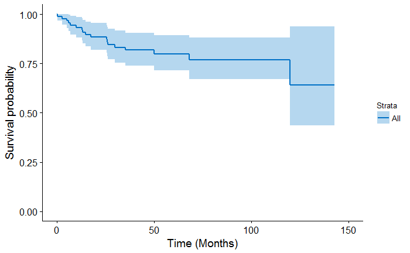

```r
uni_var(test_var = "All", data_imp = data)
```

## Facility Type

```
_________________________________________________

## FACILITY_TYPE_F
_________________________________________________
Call: survfit(formula = Surv(DX_LASTCONTACT_DEATH_MONTHS, PUF_VITAL_STATUS ==
    0) ~ FACILITY_TYPE_F, data = data)

   21 observations deleted due to missingness
                                               n events median 0.95LCL 0.95UCL
FACILITY_TYPE_F=Community Cancer Program       2      0     NA      NA      NA
FACILITY_TYPE_F=Comprehensive Comm Ca Program 24      6    120      NA      NA
FACILITY_TYPE_F=Academic/Research Program     40      9     NA      NA      NA
FACILITY_TYPE_F=Integrated Network Ca Program  5      2     NA    17.7      NA

Call: survfit(formula = Surv(DX_LASTCONTACT_DEATH_MONTHS, PUF_VITAL_STATUS ==
    0) ~ FACILITY_TYPE_F, data = data)

21 observations deleted due to missingness
                FACILITY_TYPE_F=Community Cancer Program
 time n.risk n.event survival std.err lower 95% CI upper 95% CI
   12      2       0        1       0            1            1
   24      2       0        1       0            1            1
   36      2       0        1       0            1            1
   48      1       0        1       0            1            1
   60      1       0        1       0            1            1

                FACILITY_TYPE_F=Comprehensive Comm Ca Program
 time n.risk n.event survival std.err lower 95% CI upper 95% CI
   12     22       0    1.000  0.0000        1.000        1.000
   24     17       1    0.955  0.0444        0.871        1.000
   36     14       3    0.786  0.0955        0.619        0.998
   48     11       0    0.786  0.0955        0.619        0.998
   60      8       1    0.707  0.1138        0.516        0.970

                FACILITY_TYPE_F=Academic/Research Program
 time n.risk n.event survival std.err lower 95% CI upper 95% CI
   12     32       6    0.847  0.0577        0.741        0.968
   24     27       1    0.819  0.0620        0.706        0.950
   36     24       1    0.789  0.0667        0.668        0.931
   48     18       0    0.789  0.0667        0.668        0.931
   60     18       0    0.789  0.0667        0.668        0.931
  120      3       1    0.723  0.0877        0.570        0.917

                FACILITY_TYPE_F=Integrated Network Ca Program
 time n.risk n.event survival std.err lower 95% CI upper 95% CI
   12      5       0      1.0   0.000        1.000            1
   24      3       2      0.6   0.219        0.293            1
   36      3       0      0.6   0.219        0.293            1
   48      3       0      0.6   0.219        0.293            1
   60      3       0      0.6   0.219        0.293            1





## Univariable Cox Proportional Hazard Model for:  FACILITY_TYPE_F
```

```
Loglik converged before variable  1,2,3 ; beta may be infinite.
```

```
Call:
coxph(formula = Surv(DX_LASTCONTACT_DEATH_MONTHS, PUF_VITAL_STATUS ==
    0) ~ FACILITY_TYPE_F, data = data)

  n= 71, number of events= 17
   (21 observations deleted due to missingness)

                                                  coef exp(coef)  se(coef)     z Pr(>|z|)
FACILITY_TYPE_FComprehensive Comm Ca Program 1.708e+01 2.616e+07 6.674e+03 0.003    0.998
FACILITY_TYPE_FAcademic/Research Program     1.700e+01 2.412e+07 6.674e+03 0.003    0.998
FACILITY_TYPE_FIntegrated Network Ca Program 1.762e+01 4.468e+07 6.674e+03 0.003    0.998

                                             exp(coef) exp(-coef) lower .95 upper .95
FACILITY_TYPE_FComprehensive Comm Ca Program  26157383  3.823e-08         0       Inf
FACILITY_TYPE_FAcademic/Research Program      24119879  4.146e-08         0       Inf
FACILITY_TYPE_FIntegrated Network Ca Program  44683193  2.238e-08         0       Inf

Concordance= 0.51  (se = 0.067 )
Rsquare= 0.024   (max possible= 0.838 )
Likelihood ratio test= 1.7  on 3 df,   p=0.6371
Wald test            = 0.62  on 3 df,   p=0.8924
Score (logrank) test = 1.25  on 3 df,   p=0.7412






## Unadjusted Kaplan Meier Overall Survival Curve for:  FACILITY_TYPE_F
```

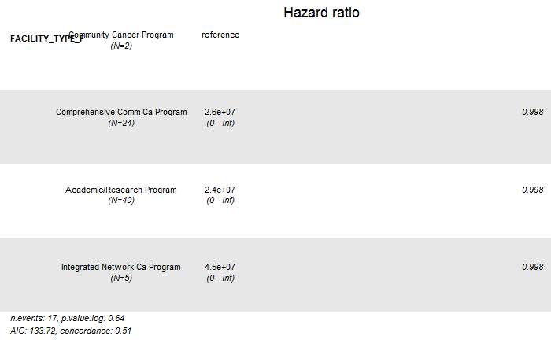

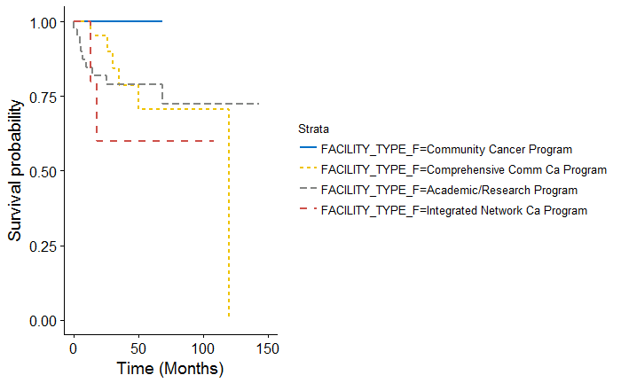

```r
uni_var(test_var = "FACILITY_TYPE_F", data_imp = data)
```

## Facility Location

```
_________________________________________________

## FACILITY_LOCATION_F
_________________________________________________
Call: survfit(formula = Surv(DX_LASTCONTACT_DEATH_MONTHS, PUF_VITAL_STATUS ==
    0) ~ FACILITY_LOCATION_F, data = data)

   21 observations deleted due to missingness
                                        n events median 0.95LCL 0.95UCL
FACILITY_LOCATION_F=New England         6      0     NA      NA      NA
FACILITY_LOCATION_F=Middle Atlantic    10      2   68.2   68.21      NA
FACILITY_LOCATION_F=South Atlantic     20      5  120.0      NA      NA
FACILITY_LOCATION_F=East North Central 11      1     NA      NA      NA
FACILITY_LOCATION_F=East South Central  3      1     NA   13.44      NA
FACILITY_LOCATION_F=West North Central  8      3     NA   14.88      NA
FACILITY_LOCATION_F=West South Central  2      1   35.3      NA      NA
FACILITY_LOCATION_F=Mountain            3      2   30.0    5.32      NA
FACILITY_LOCATION_F=Pacific             8      2     NA      NA      NA

Call: survfit(formula = Surv(DX_LASTCONTACT_DEATH_MONTHS, PUF_VITAL_STATUS ==
    0) ~ FACILITY_LOCATION_F, data = data)

21 observations deleted due to missingness
                FACILITY_LOCATION_F=New England
 time n.risk n.event survival std.err lower 95% CI upper 95% CI
   12      6       0        1       0            1            1
   24      3       0        1       0            1            1
   36      3       0        1       0            1            1
   48      3       0        1       0            1            1
   60      2       0        1       0            1            1

                FACILITY_LOCATION_F=Middle Atlantic
 time n.risk n.event survival std.err lower 95% CI upper 95% CI
   12      8       0    1.000   0.000        1.000            1
   24      8       0    1.000   0.000        1.000            1
   36      8       0    1.000   0.000        1.000            1
   48      6       0    1.000   0.000        1.000            1
   60      5       1    0.833   0.152        0.583            1

                FACILITY_LOCATION_F=South Atlantic
```

[output cut: 44 more lines]

```

                FACILITY_LOCATION_F=Pacific
 time n.risk n.event survival std.err lower 95% CI upper 95% CI
   12      6       2     0.75   0.153        0.503            1
   24      5       0     0.75   0.153        0.503            1
   36      5       0     0.75   0.153        0.503            1
   48      4       0     0.75   0.153        0.503            1
   60      4       0     0.75   0.153        0.503            1
  120      2       0     0.75   0.153        0.503            1





## Univariable Cox Proportional Hazard Model for:  FACILITY_LOCATION_F
```

```
Loglik converged before variable  1,2,3,4,5,6,7,8 ; beta may be infinite.
```

```
Call:
coxph(formula = Surv(DX_LASTCONTACT_DEATH_MONTHS, PUF_VITAL_STATUS ==
    0) ~ FACILITY_LOCATION_F, data = data)

  n= 71, number of events= 17
   (21 observations deleted due to missingness)

                                           coef exp(coef)  se(coef)     z Pr(>|z|)
FACILITY_LOCATION_FMiddle Atlantic    1.729e+01 3.228e+07 5.328e+03 0.003    0.997
FACILITY_LOCATION_FSouth Atlantic     1.746e+01 3.836e+07 5.328e+03 0.003    0.997
FACILITY_LOCATION_FEast North Central 1.644e+01 1.376e+07 5.328e+03 0.003    0.998
FACILITY_LOCATION_FEast South Central 1.782e+01 5.465e+07 5.328e+03 0.003    0.997
FACILITY_LOCATION_FWest North Central 1.805e+01 6.886e+07 5.328e+03 0.003    0.997
FACILITY_LOCATION_FWest South Central 1.837e+01 9.471e+07 5.328e+03 0.003    0.997
FACILITY_LOCATION_FMountain           1.867e+01 1.283e+08 5.328e+03 0.004    0.997
FACILITY_LOCATION_FPacific            1.737e+01 3.482e+07 5.328e+03 0.003    0.997

                                      exp(coef) exp(-coef) lower .95 upper .95
FACILITY_LOCATION_FMiddle Atlantic     32276912  3.098e-08         0       Inf
FACILITY_LOCATION_FSouth Atlantic      38357725  2.607e-08         0       Inf
FACILITY_LOCATION_FEast North Central  13762946  7.266e-08         0       Inf
FACILITY_LOCATION_FEast South Central  54649964  1.830e-08         0       Inf
FACILITY_LOCATION_FWest North Central  68864818  1.452e-08         0       Inf
FACILITY_LOCATION_FWest South Central  94709013  1.056e-08         0       Inf
FACILITY_LOCATION_FMountain           128338372  7.792e-09         0       Inf
FACILITY_LOCATION_FPacific             34820362  2.872e-08         0       Inf

Concordance= 0.686  (se = 0.074 )
Rsquare= 0.105   (max possible= 0.838 )
Likelihood ratio test= 7.88  on 8 df,   p=0.4452
Wald test            = 5.11  on 8 df,   p=0.7456
Score (logrank) test = 7.96  on 8 df,   p=0.4371






## Unadjusted Kaplan Meier Overall Survival Curve for:  FACILITY_LOCATION_F
```

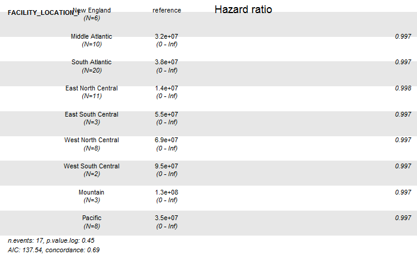

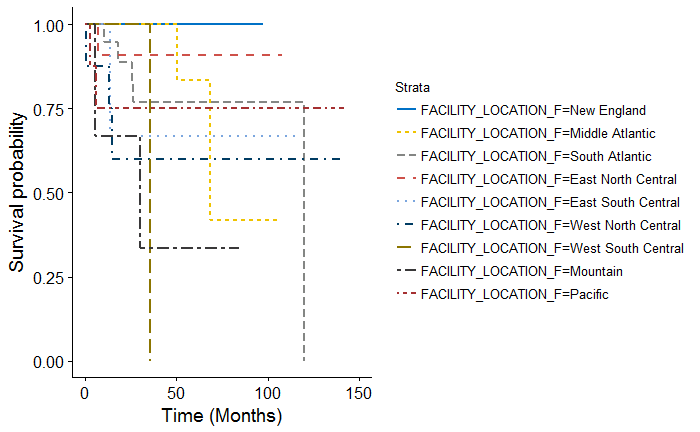

```r
uni_var(test_var = "FACILITY_LOCATION_F", data_imp = data)
```

## Facility Geography

```
_________________________________________________

## FACILITY_GEOGRAPHY
_________________________________________________
Call: survfit(formula = Surv(DX_LASTCONTACT_DEATH_MONTHS, PUF_VITAL_STATUS ==
    0) ~ FACILITY_GEOGRAPHY, data = data)

   21 observations deleted due to missingness
                              n events median 0.95LCL 0.95UCL
FACILITY_GEOGRAPHY=Northeast 16      2     NA    68.2      NA
FACILITY_GEOGRAPHY=South     22      6    120      NA      NA
FACILITY_GEOGRAPHY=Midwest   22      5     NA      NA      NA
FACILITY_GEOGRAPHY=West      11      4     NA    30.0      NA

Call: survfit(formula = Surv(DX_LASTCONTACT_DEATH_MONTHS, PUF_VITAL_STATUS ==
    0) ~ FACILITY_GEOGRAPHY, data = data)

21 observations deleted due to missingness
                FACILITY_GEOGRAPHY=Northeast
 time n.risk n.event survival std.err lower 95% CI upper 95% CI
   12     14       0    1.000   0.000        1.000            1
   24     11       0    1.000   0.000        1.000            1
   36     11       0    1.000   0.000        1.000            1
   48      9       0    1.000   0.000        1.000            1
   60      7       1    0.875   0.117        0.673            1

                FACILITY_GEOGRAPHY=South
 time n.risk n.event survival std.err lower 95% CI upper 95% CI
   12     19       1    0.952  0.0465        0.866        1.000
   24     16       1    0.899  0.0676        0.776        1.000
   36     13       3    0.731  0.1035        0.554        0.965
   48     10       0    0.731  0.1035        0.554        0.965
   60      9       0    0.731  0.1035        0.554        0.965

                FACILITY_GEOGRAPHY=Midwest
 time n.risk n.event survival std.err lower 95% CI upper 95% CI
   12     20       2    0.909  0.0613        0.797        1.000
   24     15       3    0.768  0.0912        0.608        0.969
   36     13       0    0.768  0.0912        0.608        0.969
   48      9       0    0.768  0.0912        0.608        0.969
```

[output cut: 32 more lines]

```
FACILITY_GEOGRAPHYMidwest     1.811     0.5521    0.3506     9.359
FACILITY_GEOGRAPHYWest        2.700     0.3704    0.4809    15.153

Concordance= 0.618  (se = 0.073 )
Rsquare= 0.021   (max possible= 0.838 )
Likelihood ratio test= 1.47  on 3 df,   p=0.6886
Wald test            = 1.33  on 3 df,   p=0.7232
Score (logrank) test = 1.39  on 3 df,   p=0.7089






## Unadjusted Kaplan Meier Overall Survival Curve for:  FACILITY_GEOGRAPHY
```

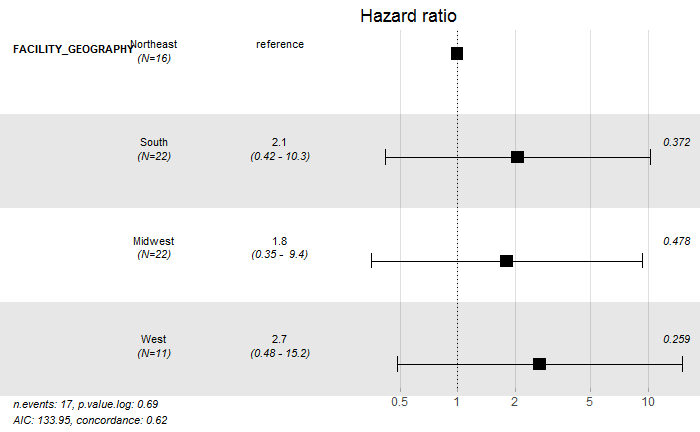

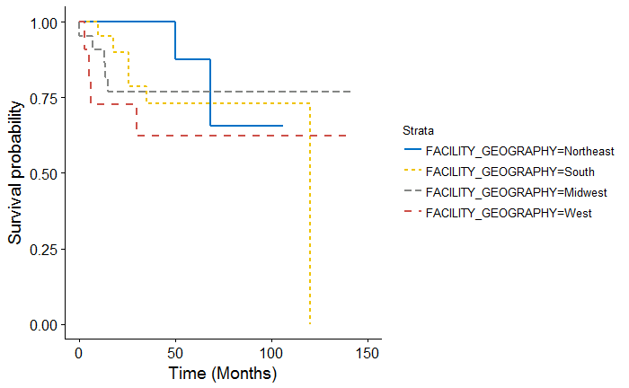

```r
uni_var(test_var = "FACILITY_GEOGRAPHY", data_imp = data)
```

## Age Group

```
_________________________________________________

## AGE_F
_________________________________________________
Call: survfit(formula = Surv(DX_LASTCONTACT_DEATH_MONTHS, PUF_VITAL_STATUS ==
    0) ~ AGE_F, data = data)

                n events median 0.95LCL 0.95UCL
AGE_F=(0,54]   46      5     NA      NA      NA
AGE_F=(54,64]  20      5     NA      NA      NA
AGE_F=(64,74]  15      5     NA    50.1      NA
AGE_F=(74,100] 11      3    120      NA      NA

Call: survfit(formula = Surv(DX_LASTCONTACT_DEATH_MONTHS, PUF_VITAL_STATUS ==
    0) ~ AGE_F, data = data)

                AGE_F=(0,54]
 time n.risk n.event survival std.err lower 95% CI upper 95% CI
   12     39       3    0.931  0.0383        0.859        1.000
   24     36       0    0.931  0.0383        0.859        1.000
   36     33       2    0.879  0.0507        0.785        0.985
   48     26       0    0.879  0.0507        0.785        0.985
   60     21       0    0.879  0.0507        0.785        0.985
  120      4       0    0.879  0.0507        0.785        0.985

                AGE_F=(54,64]
 time n.risk n.event survival std.err lower 95% CI upper 95% CI
   12     17       2    0.897  0.0689        0.772        1.000
   24     14       1    0.844  0.0826        0.697        1.000
   36     12       2    0.724  0.1061        0.543        0.965
   48     10       0    0.724  0.1061        0.543        0.965
   60     10       0    0.724  0.1061        0.543        0.965

                AGE_F=(64,74]
 time n.risk n.event survival std.err lower 95% CI upper 95% CI
   12     13       1    0.933  0.0644        0.815        1.000
   24     11       1    0.862  0.0911        0.700        1.000
   36      9       1    0.783  0.1115        0.593        1.000
   48      7       0    0.783  0.1115        0.593        1.000
   60      6       1    0.671  0.1409        0.445        1.000
```

[output cut: 31 more lines]

```
AGE_F(64,74]      3.190     0.3135    0.9217    11.039
AGE_F(74,100]     2.737     0.3653    0.6513    11.503

Concordance= 0.597  (se = 0.067 )
Rsquare= 0.048   (max possible= 0.799 )
Likelihood ratio test= 4.49  on 3 df,   p=0.2133
Wald test            = 4.04  on 3 df,   p=0.2569
Score (logrank) test = 4.43  on 3 df,   p=0.2189






## Unadjusted Kaplan Meier Overall Survival Curve for:  AGE_F
```

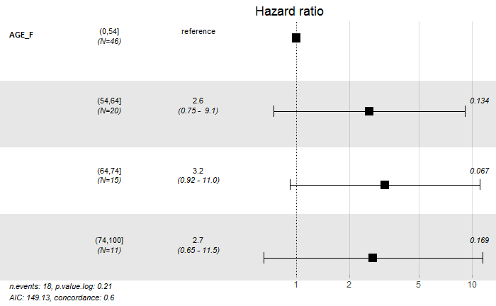

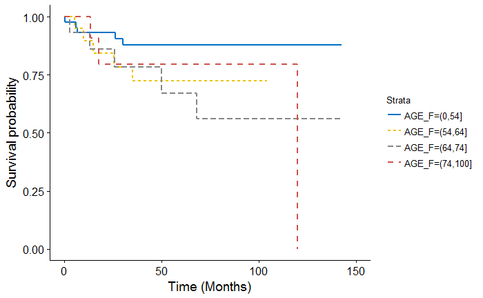

```r
uni_var(test_var = "AGE_F", data_imp = data)
```

## Age Group

```
_________________________________________________

## AGE_40
_________________________________________________
Call: survfit(formula = Surv(DX_LASTCONTACT_DEATH_MONTHS, PUF_VITAL_STATUS ==
    0) ~ AGE_40, data = data)

                 n events median 0.95LCL 0.95UCL
AGE_40=(0,40]   25      2     NA      NA      NA
AGE_40=(40,100] 67     16     NA     120      NA

Call: survfit(formula = Surv(DX_LASTCONTACT_DEATH_MONTHS, PUF_VITAL_STATUS ==
    0) ~ AGE_40, data = data)

                AGE_40=(0,40]
 time n.risk n.event survival std.err lower 95% CI upper 95% CI
   12     22       1    0.958  0.0408        0.882            1
   24     21       0    0.958  0.0408        0.882            1
   36     20       1    0.913  0.0591        0.804            1
   48     15       0    0.913  0.0591        0.804            1
   60     12       0    0.913  0.0591        0.804            1
  120      2       0    0.913  0.0591        0.804            1

                AGE_40=(40,100]
 time n.risk n.event survival std.err lower 95% CI upper 95% CI
   12     58       5    0.924  0.0327        0.862        0.990
   24     46       4    0.858  0.0440        0.776        0.949
   36     40       4    0.782  0.0541        0.683        0.896
   48     31       0    0.782  0.0541        0.683        0.896
   60     28       1    0.756  0.0582        0.650        0.879
  120      3       2    0.537  0.1631        0.296        0.974





## Univariable Cox Proportional Hazard Model for:  AGE_40

Call:
coxph(formula = Surv(DX_LASTCONTACT_DEATH_MONTHS, PUF_VITAL_STATUS ==
    0) ~ AGE_40, data = data)

  n= 92, number of events= 18

                 coef exp(coef) se(coef)     z Pr(>|z|)
AGE_40(40,100] 1.1908    3.2896   0.7508 1.586    0.113

               exp(coef) exp(-coef) lower .95 upper .95
AGE_40(40,100]      3.29      0.304    0.7552     14.33

Concordance= 0.58  (se = 0.056 )
Rsquare= 0.036   (max possible= 0.799 )
Likelihood ratio test= 3.38  on 1 df,   p=0.06582
Wald test            = 2.52  on 1 df,   p=0.1127
Score (logrank) test = 2.83  on 1 df,   p=0.09279






## Unadjusted Kaplan Meier Overall Survival Curve for:  AGE_40
```

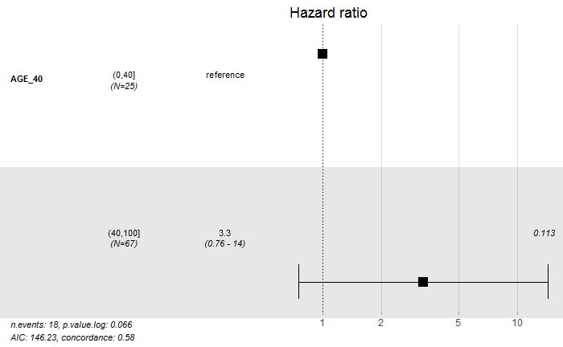

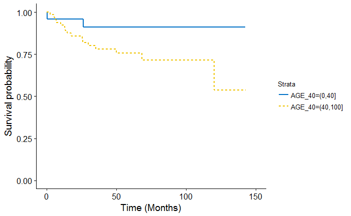

```r
uni_var(test_var = "AGE_40", data_imp = data)
```

## Gender

```
_________________________________________________

## SEX_F
_________________________________________________
Call: survfit(formula = Surv(DX_LASTCONTACT_DEATH_MONTHS, PUF_VITAL_STATUS ==
    0) ~ SEX_F, data = data)

              n events median 0.95LCL 0.95UCL
SEX_F=Male   56     12     NA     120      NA
SEX_F=Female 36      6     NA      NA      NA

Call: survfit(formula = Surv(DX_LASTCONTACT_DEATH_MONTHS, PUF_VITAL_STATUS ==
    0) ~ SEX_F, data = data)

                SEX_F=Male
 time n.risk n.event survival std.err lower 95% CI upper 95% CI
   12     51       2    0.964  0.0252        0.915        1.000
   24     43       3    0.906  0.0402        0.830        0.988
   36     38       4    0.821  0.0544        0.721        0.935
   48     26       0    0.821  0.0544        0.721        0.935
   60     25       1    0.789  0.0608        0.679        0.918
  120      4       2    0.592  0.1451        0.366        0.957

                SEX_F=Female
 time n.risk n.event survival std.err lower 95% CI upper 95% CI
   12     29       4    0.882  0.0554         0.78        0.998
   24     24       1    0.852  0.0613         0.74        0.981
   36     22       1    0.815  0.0689         0.69        0.962
   48     20       0    0.815  0.0689         0.69        0.962
   60     15       0    0.815  0.0689         0.69        0.962
  120      1       0    0.815  0.0689         0.69        0.962





## Univariable Cox Proportional Hazard Model for:  SEX_F

Call:
coxph(formula = Surv(DX_LASTCONTACT_DEATH_MONTHS, PUF_VITAL_STATUS ==
    0) ~ SEX_F, data = data)

  n= 92, number of events= 18

               coef exp(coef) se(coef)      z Pr(>|z|)
SEX_FFemale -0.1084    0.8973   0.5025 -0.216    0.829

            exp(coef) exp(-coef) lower .95 upper .95
SEX_FFemale    0.8973      1.114    0.3351     2.402

Concordance= 0.483  (se = 0.061 )
Rsquare= 0.001   (max possible= 0.799 )
Likelihood ratio test= 0.05  on 1 df,   p=0.8282
Wald test            = 0.05  on 1 df,   p=0.8292
Score (logrank) test = 0.05  on 1 df,   p=0.8291






## Unadjusted Kaplan Meier Overall Survival Curve for:  SEX_F
```

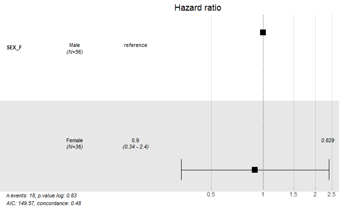

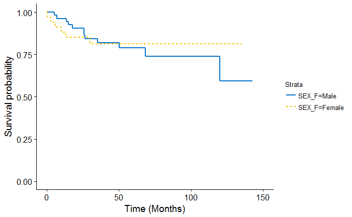

```r
uni_var(test_var = "SEX_F", data_imp = data)
```

## RACE_F

```
_________________________________________________

## RACE_F
_________________________________________________
Call: survfit(formula = Surv(DX_LASTCONTACT_DEATH_MONTHS, PUF_VITAL_STATUS ==
    0) ~ RACE_F, data = data)

                  n events median 0.95LCL 0.95UCL
RACE_F=White     67     12     NA      NA      NA
RACE_F=Black     15      5    120    68.2      NA
RACE_F=Other/Unk  8      1     NA      NA      NA
RACE_F=Asian      2      0     NA      NA      NA

Call: survfit(formula = Surv(DX_LASTCONTACT_DEATH_MONTHS, PUF_VITAL_STATUS ==
    0) ~ RACE_F, data = data)

                RACE_F=White
 time n.risk n.event survival std.err lower 95% CI upper 95% CI
   12     55       6    0.906  0.0364        0.838        0.981
   24     46       3    0.856  0.0444        0.774        0.948
   36     41       3    0.800  0.0521        0.704        0.909
   48     28       0    0.800  0.0521        0.704        0.909
   60     26       0    0.800  0.0521        0.704        0.909
  120      3       0    0.800  0.0521        0.704        0.909

                RACE_F=Black
 time n.risk n.event survival std.err lower 95% CI upper 95% CI
   12     15       0    1.000  0.0000       1.0000            1
   24     14       1    0.933  0.0644       0.8153            1
   36     13       1    0.867  0.0878       0.7106            1
   48     12       0    0.867  0.0878       0.7106            1
   60      9       1    0.794  0.1061       0.6115            1
  120      1       2    0.340  0.2506       0.0805            1

                RACE_F=Other/Unk
 time n.risk n.event survival std.err lower 95% CI upper 95% CI
   12      8       0      1.0   0.000        1.000            1
   24      5       0      1.0   0.000        1.000            1
   36      4       1      0.8   0.179        0.516            1
   48      4       0      0.8   0.179        0.516            1
   60      3       0      0.8   0.179        0.516            1
  120      1       0      0.8   0.179        0.516            1

                RACE_F=Asian
 time n.risk n.event survival std.err lower 95% CI upper 95% CI
   12      2       0        1       0            1            1
   24      2       0        1       0            1            1
   36      2       0        1       0            1            1
   48      2       0        1       0            1            1
   60      2       0        1       0            1            1





## Univariable Cox Proportional Hazard Model for:  RACE_F
```

```
Loglik converged before variable  3 ; beta may be infinite.
```

```
Call:
coxph(formula = Surv(DX_LASTCONTACT_DEATH_MONTHS, PUF_VITAL_STATUS ==
    0) ~ RACE_F, data = data)

  n= 92, number of events= 18

                      coef  exp(coef)   se(coef)      z Pr(>|z|)
RACE_FBlack      3.067e-01  1.359e+00  5.361e-01  0.572    0.567
RACE_FOther/Unk -4.914e-01  6.118e-01  1.043e+00 -0.471    0.638
RACE_FAsian     -1.703e+01  4.036e-08  7.214e+03 -0.002    0.998

                exp(coef) exp(-coef) lower .95 upper .95
RACE_FBlack     1.359e+00  7.359e-01   0.47522     3.886
RACE_FOther/Unk 6.118e-01  1.635e+00   0.07918     4.727
RACE_FAsian     4.036e-08  2.478e+07   0.00000       Inf

Concordance= 0.52  (se = 0.059 )
Rsquare= 0.018   (max possible= 0.799 )
Likelihood ratio test= 1.66  on 3 df,   p=0.6462
Wald test            = 0.65  on 3 df,   p=0.8856
Score (logrank) test = 1.18  on 3 df,   p=0.7588






## Unadjusted Kaplan Meier Overall Survival Curve for:  RACE_F
```

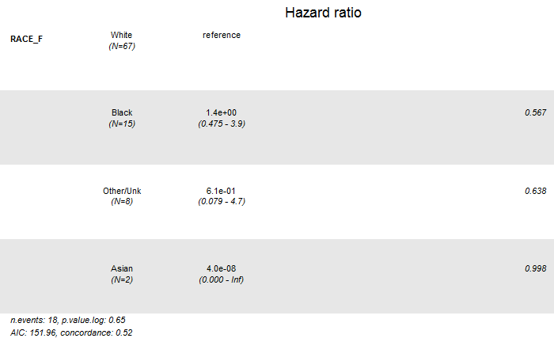

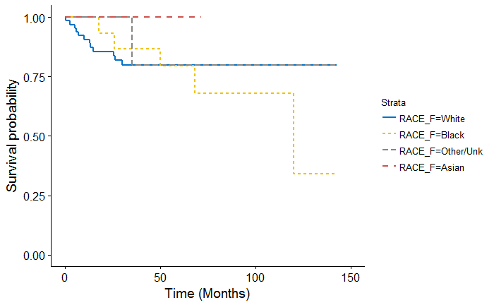

```r
uni_var(test_var = "RACE_F", data_imp = data)
```

## Hispanic

```
_________________________________________________

## HISPANIC
_________________________________________________
Call: survfit(formula = Surv(DX_LASTCONTACT_DEATH_MONTHS, PUF_VITAL_STATUS ==
    0) ~ HISPANIC, data = data)

                  n events median 0.95LCL 0.95UCL
HISPANIC=No      81     16     NA   120.0      NA
HISPANIC=Yes      8      1     NA      NA      NA
HISPANIC=Unknown  3      1     NA    35.3      NA

Call: survfit(formula = Surv(DX_LASTCONTACT_DEATH_MONTHS, PUF_VITAL_STATUS ==
    0) ~ HISPANIC, data = data)

                HISPANIC=No
 time n.risk n.event survival std.err lower 95% CI upper 95% CI
   12     71       5    0.936  0.0276        0.884        0.992
   24     59       4    0.882  0.0370        0.812        0.958
   36     53       4    0.822  0.0451        0.738        0.915
   48     40       0    0.822  0.0451        0.738        0.915
   60     34       1    0.801  0.0486        0.711        0.902
  120      5       2    0.640  0.1260        0.435        0.941

                HISPANIC=Yes
 time n.risk n.event survival std.err lower 95% CI upper 95% CI
   12      6       1    0.875   0.117        0.673            1
   24      5       0    0.875   0.117        0.673            1
   36      5       0    0.875   0.117        0.673            1
   48      4       0    0.875   0.117        0.673            1
   60      4       0    0.875   0.117        0.673            1

                HISPANIC=Unknown
 time n.risk n.event survival std.err lower 95% CI upper 95% CI
   12      3       0    1.000   0.000          1.0            1
   24      3       0    1.000   0.000          1.0            1
   36      2       1    0.667   0.272          0.3            1
   48      2       0    0.667   0.272          0.3            1
   60      2       0    0.667   0.272          0.3            1

```

[output cut: 17 more lines]

```
HISPANICYes        0.7201     1.3887   0.09508     5.454
HISPANICUnknown    1.5572     0.6422   0.20466    11.848

Concordance= 0.511  (se = 0.041 )
Rsquare= 0.003   (max possible= 0.799 )
Likelihood ratio test= 0.29  on 2 df,   p=0.865
Wald test            = 0.3  on 2 df,   p=0.8598
Score (logrank) test = 0.31  on 2 df,   p=0.8574






## Unadjusted Kaplan Meier Overall Survival Curve for:  HISPANIC
```

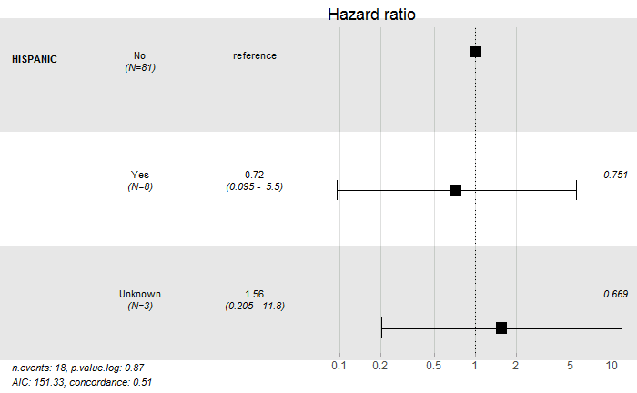

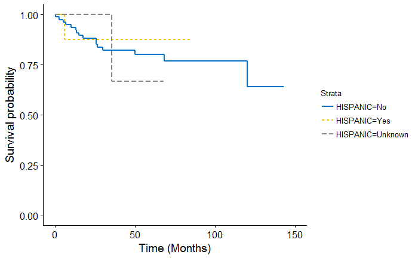

```r
uni_var(test_var = "HISPANIC", data_imp = data)
```

## Insurance Status

```
_________________________________________________

## INSURANCE_F
_________________________________________________
Call: survfit(formula = Surv(DX_LASTCONTACT_DEATH_MONTHS, PUF_VITAL_STATUS ==
    0) ~ INSURANCE_F, data = data)

                              n events median 0.95LCL 0.95UCL
INSURANCE_F=Private          54      9     NA      NA      NA
INSURANCE_F=None              7      1     NA      NA      NA
INSURANCE_F=Medicaid          5      2     NA    26.4      NA
INSURANCE_F=Medicare         21      5    120   120.0      NA
INSURANCE_F=Other Government  1      0     NA      NA      NA
INSURANCE_F=Unknown           4      1     NA    14.9      NA

Call: survfit(formula = Surv(DX_LASTCONTACT_DEATH_MONTHS, PUF_VITAL_STATUS ==
    0) ~ INSURANCE_F, data = data)

                INSURANCE_F=Private
 time n.risk n.event survival std.err lower 95% CI upper 95% CI
   12     44       4    0.921  0.0378        0.850        0.998
   24     39       0    0.921  0.0378        0.850        0.998
   36     34       4    0.826  0.0564        0.723        0.944
   48     27       0    0.826  0.0564        0.723        0.944
   60     23       0    0.826  0.0564        0.723        0.944
  120      3       1    0.763  0.0802        0.621        0.937

                INSURANCE_F=None
 time n.risk n.event survival std.err lower 95% CI upper 95% CI
   12      6       1    0.857   0.132        0.633            1
   24      6       0    0.857   0.132        0.633            1
   36      6       0    0.857   0.132        0.633            1
   48      4       0    0.857   0.132        0.633            1
   60      4       0    0.857   0.132        0.633            1
  120      1       0    0.857   0.132        0.633            1

                INSURANCE_F=Medicaid
 time n.risk n.event survival std.err lower 95% CI upper 95% CI
   12      5       0      1.0   0.000        1.000            1
   24      4       1      0.8   0.179        0.516            1
```

[output cut: 19 more lines]

```
   60      1       0        1       0            1            1

                INSURANCE_F=Unknown
 time n.risk n.event survival std.err lower 95% CI upper 95% CI
   12      4       0     1.00   0.000        1.000            1
   24      2       1     0.75   0.217        0.426            1
   36      2       0     0.75   0.217        0.426            1
   48      1       0     0.75   0.217        0.426            1
   60      1       0     0.75   0.217        0.426            1





## Univariable Cox Proportional Hazard Model for:  INSURANCE_F
```

```
Loglik converged before variable  4 ; beta may be infinite.
```

```
Call:
coxph(formula = Surv(DX_LASTCONTACT_DEATH_MONTHS, PUF_VITAL_STATUS ==
    0) ~ INSURANCE_F, data = data)

  n= 92, number of events= 18

                                  coef  exp(coef)   se(coef)      z Pr(>|z|)
INSURANCE_FNone             -3.397e-01  7.120e-01  1.056e+00 -0.322    0.748
INSURANCE_FMedicaid          8.262e-01  2.285e+00  7.844e-01  1.053    0.292
INSURANCE_FMedicare          2.549e-01  1.290e+00  5.589e-01  0.456    0.648
INSURANCE_FOther Government -1.595e+01  1.181e-07  6.067e+03 -0.003    0.998
INSURANCE_FUnknown           4.982e-01  1.646e+00  1.057e+00  0.471    0.637

                            exp(coef) exp(-coef) lower .95 upper .95
INSURANCE_FNone             7.120e-01  1.405e+00   0.08985     5.642
INSURANCE_FMedicaid         2.285e+00  4.377e-01   0.49107    10.629
INSURANCE_FMedicare         1.290e+00  7.750e-01   0.43145     3.859
INSURANCE_FOther Government 1.181e-07  8.469e+06   0.00000       Inf
INSURANCE_FUnknown          1.646e+00  6.076e-01   0.20731    13.065

Concordance= 0.559  (se = 0.065 )
Rsquare= 0.021   (max possible= 0.799 )
Likelihood ratio test= 1.91  on 5 df,   p=0.862
Wald test            = 1.51  on 5 df,   p=0.9119
Score (logrank) test = 1.87  on 5 df,   p=0.8669






## Unadjusted Kaplan Meier Overall Survival Curve for:  INSURANCE_F
```

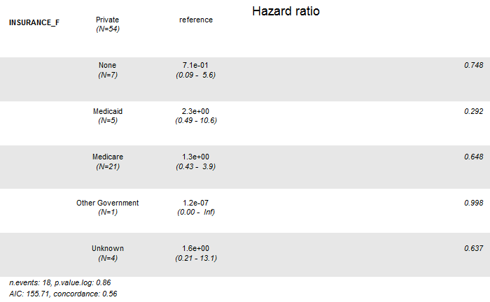

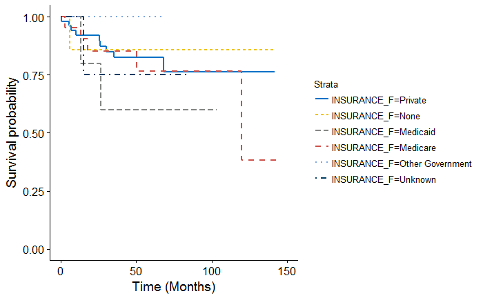

```r
uni_var(test_var = "INSURANCE_F", data_imp = data)
```

## Income

```
_________________________________________________

## INCOME_F
_________________________________________________
Call: survfit(formula = Surv(DX_LASTCONTACT_DEATH_MONTHS, PUF_VITAL_STATUS ==
    0) ~ INCOME_F, data = data)

   1 observation deleted due to missingness
                            n events median 0.95LCL 0.95UCL
INCOME_F=Less than $38,000 15      5     NA    50.1      NA
INCOME_F=$38,000 - $47,999 32      5     NA   120.0      NA
INCOME_F=$48,000 - $62,999 18      3     NA      NA      NA
INCOME_F=$63,000 +         26      4     NA      NA      NA

Call: survfit(formula = Surv(DX_LASTCONTACT_DEATH_MONTHS, PUF_VITAL_STATUS ==
    0) ~ INCOME_F, data = data)

1 observation deleted due to missingness
                INCOME_F=Less than $38,000
 time n.risk n.event survival std.err lower 95% CI upper 95% CI
   12     13       1    0.933  0.0644        0.815        1.000
   24     10       2    0.790  0.1081        0.604        1.000
   36      9       1    0.711  0.1228        0.507        0.997
   48      6       0    0.711  0.1228        0.507        0.997
   60      5       1    0.592  0.1489        0.362        0.969

                INCOME_F=$38,000 - $47,999
 time n.risk n.event survival std.err lower 95% CI upper 95% CI
   12     28       1    0.969  0.0308        0.910            1
   24     21       1    0.933  0.0460        0.847            1
   36     18       2    0.842  0.0740        0.708            1
   48     15       0    0.842  0.0740        0.708            1
   60     14       0    0.842  0.0740        0.708            1
  120      2       1    0.561  0.2343        0.248            1

                INCOME_F=$48,000 - $62,999
 time n.risk n.event survival std.err lower 95% CI upper 95% CI
   12     15       2    0.889  0.0741        0.755            1
   24     15       0    0.889  0.0741        0.755            1
   36     13       1    0.830  0.0898        0.671            1
```

[output cut: 33 more lines]

```
INCOME_F$48,000 - $62,999    0.4202      2.380   0.09971     1.771
INCOME_F$63,000 +            0.3879      2.578   0.10297     1.461

Concordance= 0.584  (se = 0.072 )
Rsquare= 0.026   (max possible= 0.783 )
Likelihood ratio test= 2.43  on 3 df,   p=0.4887
Wald test            = 2.76  on 3 df,   p=0.4297
Score (logrank) test = 2.95  on 3 df,   p=0.3991






## Unadjusted Kaplan Meier Overall Survival Curve for:  INCOME_F
```

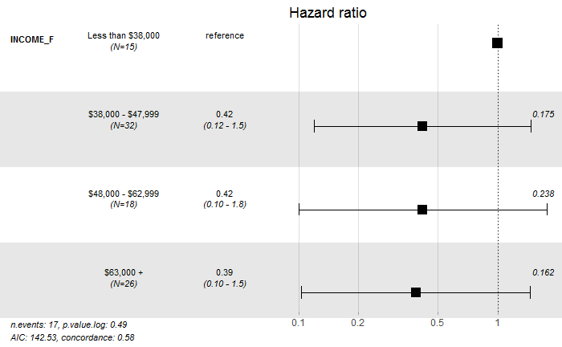

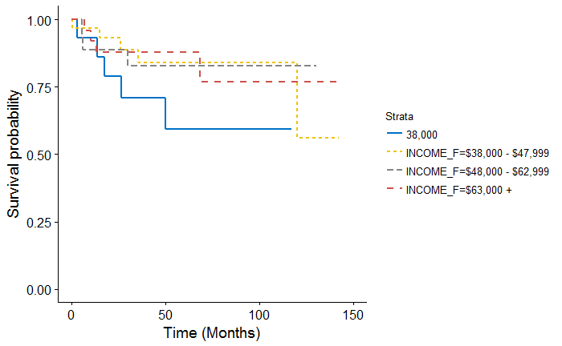

```r
uni_var(test_var = "INCOME_F", data_imp = data)
```

## Education

```
_________________________________________________

## EDUCATION_F
_________________________________________________
Call: survfit(formula = Surv(DX_LASTCONTACT_DEATH_MONTHS, PUF_VITAL_STATUS ==
    0) ~ EDUCATION_F, data = data)

   1 observation deleted due to missingness
                          n events median 0.95LCL 0.95UCL
EDUCATION_F=21% or more  17      4     NA    50.1      NA
EDUCATION_F=13 - 20.9%   27      6    120   120.0      NA
EDUCATION_F=7 - 12.9%    27      3     NA      NA      NA
EDUCATION_F=Less than 7% 20      4     NA      NA      NA

Call: survfit(formula = Surv(DX_LASTCONTACT_DEATH_MONTHS, PUF_VITAL_STATUS ==
    0) ~ EDUCATION_F, data = data)

1 observation deleted due to missingness
                EDUCATION_F=21% or more
 time n.risk n.event survival std.err lower 95% CI upper 95% CI
   12     15       1    0.941  0.0571        0.836            1
   24     12       1    0.874  0.0837        0.724            1
   36     11       1    0.801  0.1037        0.622            1
   48      9       0    0.801  0.1037        0.622            1
   60      6       1    0.701  0.1304        0.487            1

                EDUCATION_F=13 - 20.9%
 time n.risk n.event survival std.err lower 95% CI upper 95% CI
   12     21       2    0.921  0.0533       0.8227        1.000
   24     16       1    0.875  0.0677       0.7523        1.000
   36     14       2    0.766  0.0935       0.6029        0.973
   48     11       0    0.766  0.0935       0.6029        0.973
   60     10       0    0.766  0.0935       0.6029        0.973
  120      1       1    0.383  0.2748       0.0938        1.000

                EDUCATION_F=7 - 12.9%
 time n.risk n.event survival std.err lower 95% CI upper 95% CI
   12     25       1    0.963  0.0363        0.894            1
   24     22       1    0.924  0.0514        0.829            1
   36     20       1    0.882  0.0640        0.766            1
```

[output cut: 33 more lines]

```
EDUCATION_F7 - 12.9%       0.4049     2.4694   0.08998     1.822
EDUCATION_FLess than 7%    0.6929     1.4433   0.17078     2.811

Concordance= 0.577  (se = 0.072 )
Rsquare= 0.024   (max possible= 0.783 )
Likelihood ratio test= 2.18  on 3 df,   p=0.5356
Wald test            = 1.96  on 3 df,   p=0.5811
Score (logrank) test = 2.07  on 3 df,   p=0.5587






## Unadjusted Kaplan Meier Overall Survival Curve for:  EDUCATION_F
```

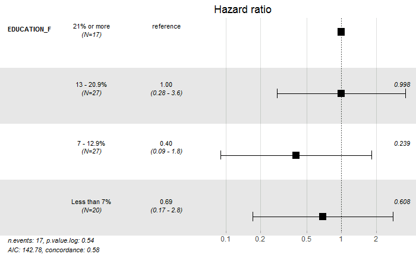

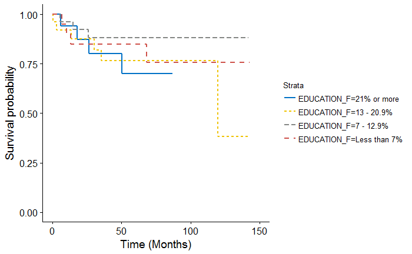

```r
uni_var(test_var = "EDUCATION_F", data_imp = data)
```

## Urban/Rural

```
_________________________________________________

## U_R_F
_________________________________________________
Call: survfit(formula = Surv(DX_LASTCONTACT_DEATH_MONTHS, PUF_VITAL_STATUS ==
    0) ~ U_R_F, data = data)

   3 observations deleted due to missingness
             n events median 0.95LCL 0.95UCL
U_R_F=Metro 74     11     NA   120.0      NA
U_R_F=Urban 14      5     NA    14.9      NA
U_R_F=Rural  1      0     NA      NA      NA

Call: survfit(formula = Surv(DX_LASTCONTACT_DEATH_MONTHS, PUF_VITAL_STATUS ==
    0) ~ U_R_F, data = data)

3 observations deleted due to missingness
                U_R_F=Metro
 time n.risk n.event survival std.err lower 95% CI upper 95% CI
   12     67       3    0.959  0.0235        0.914        1.000
   24     58       2    0.929  0.0308        0.870        0.991
   36     53       3    0.880  0.0399        0.806        0.962
   48     40       0    0.880  0.0399        0.806        0.962
   60     34       1    0.858  0.0448        0.774        0.950
  120      5       2    0.684  0.1334        0.467        1.000

                U_R_F=Urban
 time n.risk n.event survival std.err lower 95% CI upper 95% CI
   12     11       2    0.846   0.100        0.671        1.000
   24      7       2    0.692   0.128        0.482        0.995
   36      6       1    0.593   0.143        0.370        0.951
   48      5       0    0.593   0.143        0.370        0.951
   60      5       0    0.593   0.143        0.370        0.951

                U_R_F=Rural
     time n.risk n.event survival std.err lower 95% CI upper 95% CI





## Univariable Cox Proportional Hazard Model for:  U_R_F
```

```
Loglik converged before variable  2 ; beta may be infinite.
```

```
Call:
coxph(formula = Surv(DX_LASTCONTACT_DEATH_MONTHS, PUF_VITAL_STATUS ==
    0) ~ U_R_F, data = data)

  n= 89, number of events= 16
   (3 observations deleted due to missingness)

                 coef  exp(coef)   se(coef)      z Pr(>|z|)
U_R_FUrban  1.256e+00  3.510e+00  5.495e-01  2.285   0.0223 *
U_R_FRural -1.308e+01  2.081e-06  5.310e+03 -0.002   0.9980
---
Signif. codes:  0 *** 0.001 ** 0.01 * 0.05 . 0.1   1

           exp(coef) exp(-coef) lower .95 upper .95
U_R_FUrban 3.510e+00  2.849e-01     1.196      10.3
U_R_FRural 2.081e-06  4.806e+05     0.000       Inf

Concordance= 0.622  (se = 0.046 )
Rsquare= 0.048   (max possible= 0.767 )
Likelihood ratio test= 4.42  on 2 df,   p=0.1099
Wald test            = 5.22  on 2 df,   p=0.07343
Score (logrank) test = 5.97  on 2 df,   p=0.05045






## Unadjusted Kaplan Meier Overall Survival Curve for:  U_R_F
```

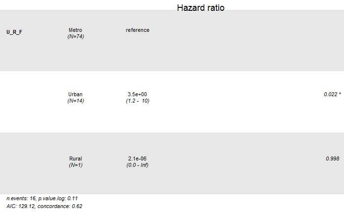

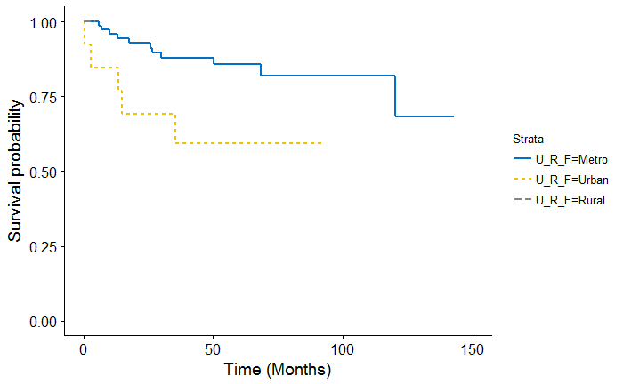

```r
uni_var(test_var = "U_R_F", data_imp = data)
```

## Comorbidities

```
_________________________________________________

## CDCC_TOTAL
_________________________________________________
Call: survfit(formula = Surv(DX_LASTCONTACT_DEATH_MONTHS, PUF_VITAL_STATUS ==
    0) ~ CDCC_TOTAL, data = data)

              n events median 0.95LCL 0.95UCL
CDCC_TOTAL=0 77     13     NA   120.0      NA
CDCC_TOTAL=1 12      4     NA    35.3      NA
CDCC_TOTAL=2  2      0     NA      NA      NA
CDCC_TOTAL=3  1      1   50.1      NA      NA

Call: survfit(formula = Surv(DX_LASTCONTACT_DEATH_MONTHS, PUF_VITAL_STATUS ==
    0) ~ CDCC_TOTAL, data = data)

                CDCC_TOTAL=0
 time n.risk n.event survival std.err lower 95% CI upper 95% CI
   12     69       4    0.947  0.0259        0.897        0.999
   24     58       3    0.904  0.0345        0.839        0.974
   36     52       4    0.842  0.0441        0.759        0.933
   48     41       0    0.842  0.0441        0.759        0.933
   60     36       0    0.842  0.0441        0.759        0.933
  120      5       2    0.673  0.1308        0.460        0.985

                CDCC_TOTAL=1
 time n.risk n.event survival std.err lower 95% CI upper 95% CI
   12     10       2    0.833   0.108        0.647        1.000
   24      8       1    0.750   0.125        0.541        1.000
   36      7       1    0.656   0.140        0.432        0.997
   48      4       0    0.656   0.140        0.432        0.997
   60      4       0    0.656   0.140        0.432        0.997

                CDCC_TOTAL=2
     time n.risk n.event survival std.err lower 95% CI upper 95% CI

                CDCC_TOTAL=3
 time n.risk n.event survival std.err lower 95% CI upper 95% CI
   12      1       0        1       0            1            1
   24      1       0        1       0            1            1
   36      1       0        1       0            1            1
   48      1       0        1       0            1            1





## Univariable Cox Proportional Hazard Model for:  CDCC_TOTAL
```

```
Loglik converged before variable  2 ; beta may be infinite.
```

```
Call:
coxph(formula = Surv(DX_LASTCONTACT_DEATH_MONTHS, PUF_VITAL_STATUS ==
    0) ~ CDCC_TOTAL, data = data)

  n= 92, number of events= 18

                  coef  exp(coef)   se(coef)      z Pr(>|z|)
CDCC_TOTAL1  8.941e-01  2.445e+00  5.805e-01  1.540   0.1235
CDCC_TOTAL2 -1.438e+01  5.710e-07  5.188e+03 -0.003   0.9978
CDCC_TOTAL3  1.721e+00  5.592e+00  1.045e+00  1.647   0.0995 .
---
Signif. codes:  0 *** 0.001 ** 0.01 * 0.05 . 0.1   1

            exp(coef) exp(-coef) lower .95 upper .95
CDCC_TOTAL1 2.445e+00  4.090e-01    0.7838     7.628
CDCC_TOTAL2 5.710e-07  1.751e+06    0.0000       Inf
CDCC_TOTAL3 5.592e+00  1.788e-01    0.7214    43.350

Concordance= 0.581  (se = 0.044 )
Rsquare= 0.039   (max possible= 0.799 )
Likelihood ratio test= 3.67  on 3 df,   p=0.2989
Wald test            = 4.45  on 3 df,   p=0.2167
Score (logrank) test = 5.28  on 3 df,   p=0.1526






## Unadjusted Kaplan Meier Overall Survival Curve for:  CDCC_TOTAL
```

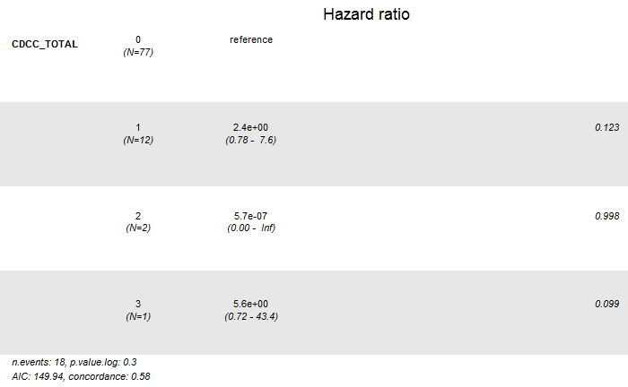

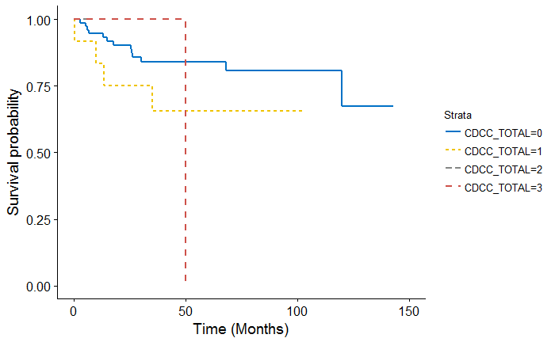

```r
uni_var(test_var = "CDCC_TOTAL", data_imp = data)
```

## Class (treatment at performing facility)

```
_________________________________________________

## CLASS_OF_CASE_F
_________________________________________________
Call: survfit(formula = Surv(DX_LASTCONTACT_DEATH_MONTHS, PUF_VITAL_STATUS ==
    0) ~ CLASS_OF_CASE_F, data = data)

                                n events median 0.95LCL 0.95UCL
CLASS_OF_CASE_F=Other_Facility  6      2   17.7    13.1      NA
CLASS_OF_CASE_F=All_Part_Prim  86     16     NA   120.0      NA

Call: survfit(formula = Surv(DX_LASTCONTACT_DEATH_MONTHS, PUF_VITAL_STATUS ==
    0) ~ CLASS_OF_CASE_F, data = data)

                CLASS_OF_CASE_F=Other_Facility
 time n.risk n.event survival std.err lower 95% CI upper 95% CI
   12      4       0    1.000   0.000       1.0000            1
   24      1       2    0.375   0.286       0.0839            1
   36      1       0    0.375   0.286       0.0839            1

                CLASS_OF_CASE_F=All_Part_Prim
 time n.risk n.event survival std.err lower 95% CI upper 95% CI
   12     76       6    0.929  0.0280        0.875        0.985
   24     66       2    0.904  0.0323        0.843        0.970
   36     59       5    0.835  0.0421        0.756        0.922
   48     46       0    0.835  0.0421        0.756        0.922
   60     40       1    0.816  0.0451        0.733        0.910
  120      5       2    0.654  0.1274        0.447        0.958





## Univariable Cox Proportional Hazard Model for:  CLASS_OF_CASE_F

Call:
coxph(formula = Surv(DX_LASTCONTACT_DEATH_MONTHS, PUF_VITAL_STATUS ==
    0) ~ CLASS_OF_CASE_F, data = data)

  n= 92, number of events= 18

                                coef exp(coef) se(coef)      z Pr(>|z|)
CLASS_OF_CASE_FAll_Part_Prim -1.3885    0.2494   0.7709 -1.801   0.0717 .
---
Signif. codes:  0 *** 0.001 ** 0.01 * 0.05 . 0.1   1

                             exp(coef) exp(-coef) lower .95 upper .95
CLASS_OF_CASE_FAll_Part_Prim    0.2494      4.009   0.05505      1.13

Concordance= 0.544  (se = 0.025 )
Rsquare= 0.025   (max possible= 0.799 )
Likelihood ratio test= 2.36  on 1 df,   p=0.1248
Wald test            = 3.24  on 1 df,   p=0.07168
Score (logrank) test = 3.79  on 1 df,   p=0.05145






## Unadjusted Kaplan Meier Overall Survival Curve for:  CLASS_OF_CASE_F
```

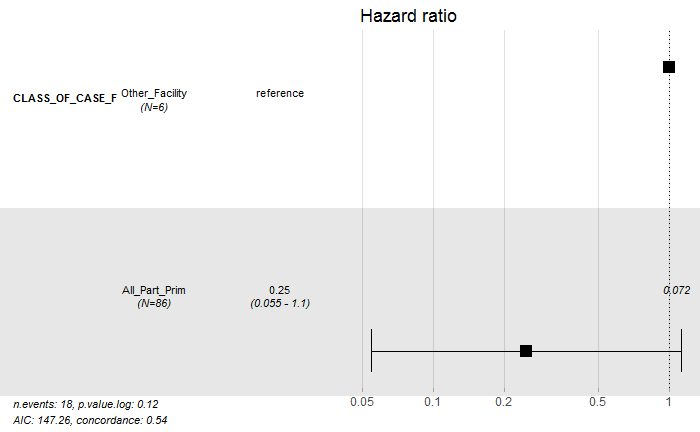

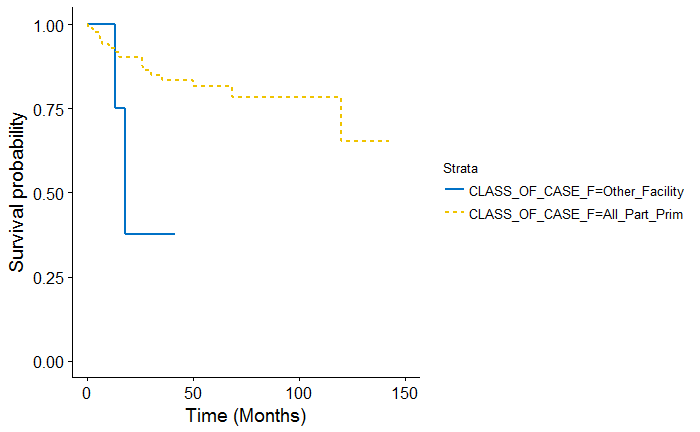

```r
uni_var(test_var = "CLASS_OF_CASE_F", data_imp = data)
```

## Year

```
_________________________________________________

## YEAR_OF_DIAGNOSIS
_________________________________________________
Call: survfit(formula = Surv(DX_LASTCONTACT_DEATH_MONTHS, PUF_VITAL_STATUS ==
    0) ~ YEAR_OF_DIAGNOSIS, data = data)

                        n events median 0.95LCL 0.95UCL
YEAR_OF_DIAGNOSIS=2004  6      2     NA    6.93      NA
YEAR_OF_DIAGNOSIS=2005  4      2    120   68.21      NA
YEAR_OF_DIAGNOSIS=2006  6      1     NA      NA      NA
YEAR_OF_DIAGNOSIS=2007  7      2     NA   25.92      NA
YEAR_OF_DIAGNOSIS=2008  8      2     NA      NA      NA
YEAR_OF_DIAGNOSIS=2009  4      0     NA      NA      NA
YEAR_OF_DIAGNOSIS=2010 13      2     NA      NA      NA
YEAR_OF_DIAGNOSIS=2011  9      0     NA      NA      NA
YEAR_OF_DIAGNOSIS=2012 13      2     NA   50.14      NA
YEAR_OF_DIAGNOSIS=2013 10      3     NA   30.03      NA
YEAR_OF_DIAGNOSIS=2014 12      2     NA      NA      NA

Call: survfit(formula = Surv(DX_LASTCONTACT_DEATH_MONTHS, PUF_VITAL_STATUS ==
    0) ~ YEAR_OF_DIAGNOSIS, data = data)

                YEAR_OF_DIAGNOSIS=2004
 time n.risk n.event survival std.err lower 95% CI upper 95% CI
   12      4       2    0.667   0.192        0.379            1
   24      4       0    0.667   0.192        0.379            1
   36      4       0    0.667   0.192        0.379            1
   48      3       0    0.667   0.192        0.379            1
   60      3       0    0.667   0.192        0.379            1
  120      3       0    0.667   0.192        0.379            1

                YEAR_OF_DIAGNOSIS=2005
 time n.risk n.event survival std.err lower 95% CI upper 95% CI
   12      4       0    1.000   0.000       1.0000            1
   24      4       0    1.000   0.000       1.0000            1
   36      4       0    1.000   0.000       1.0000            1
   48      4       0    1.000   0.000       1.0000            1
   60      4       0    1.000   0.000       1.0000            1
  120      1       2    0.333   0.272       0.0673            1
```

[output cut: 58 more lines]

```
 time n.risk n.event survival std.err lower 95% CI upper 95% CI
   12     10       0    1.000  0.0000        1.000            1
   24      7       1    0.900  0.0949        0.732            1
   36      5       2    0.643  0.1679        0.385            1

                YEAR_OF_DIAGNOSIS=2014
 time n.risk n.event survival std.err lower 95% CI upper 95% CI
   12      7       1    0.889   0.105        0.706            1
   24      1       1    0.762   0.148        0.521            1





## Univariable Cox Proportional Hazard Model for:  YEAR_OF_DIAGNOSIS
```

```
Loglik converged before variable  5,7 ; beta may be infinite.
```

```
Call:
coxph(formula = Surv(DX_LASTCONTACT_DEATH_MONTHS, PUF_VITAL_STATUS ==
    0) ~ YEAR_OF_DIAGNOSIS, data = data)

  n= 92, number of events= 18

                            coef  exp(coef)   se(coef)      z Pr(>|z|)
YEAR_OF_DIAGNOSIS2005  1.173e-01  1.124e+00  1.003e+00  0.117    0.907
YEAR_OF_DIAGNOSIS2006 -6.367e-01  5.290e-01  1.240e+00 -0.514    0.608
YEAR_OF_DIAGNOSIS2007  1.013e-01  1.107e+00  1.043e+00  0.097    0.923
YEAR_OF_DIAGNOSIS2008 -1.459e-01  8.643e-01  1.043e+00 -0.140    0.889
YEAR_OF_DIAGNOSIS2009 -1.856e+01  8.657e-09  9.150e+03 -0.002    0.998
YEAR_OF_DIAGNOSIS2010 -6.757e-01  5.088e-01  1.043e+00 -0.648    0.517
YEAR_OF_DIAGNOSIS2011 -1.857e+01  8.608e-09  6.350e+03 -0.003    0.998
YEAR_OF_DIAGNOSIS2012 -5.155e-01  5.972e-01  1.050e+00 -0.491    0.623
YEAR_OF_DIAGNOSIS2013  2.708e-01  1.311e+00  9.716e-01  0.279    0.780
YEAR_OF_DIAGNOSIS2014  3.701e-01  1.448e+00  1.073e+00  0.345    0.730

                      exp(coef) exp(-coef) lower .95 upper .95
YEAR_OF_DIAGNOSIS2005 1.124e+00  8.893e-01   0.15741     8.033
YEAR_OF_DIAGNOSIS2006 5.290e-01  1.890e+00   0.04656     6.010
YEAR_OF_DIAGNOSIS2007 1.107e+00  9.036e-01   0.14332     8.545
YEAR_OF_DIAGNOSIS2008 8.643e-01  1.157e+00   0.11189     6.676
YEAR_OF_DIAGNOSIS2009 8.657e-09  1.155e+08   0.00000       Inf
YEAR_OF_DIAGNOSIS2010 5.088e-01  1.965e+00   0.06585     3.932
YEAR_OF_DIAGNOSIS2011 8.608e-09  1.162e+08   0.00000       Inf
YEAR_OF_DIAGNOSIS2012 5.972e-01  1.675e+00   0.07634     4.672
YEAR_OF_DIAGNOSIS2013 1.311e+00  7.628e-01   0.19526     8.802
YEAR_OF_DIAGNOSIS2014 1.448e+00  6.906e-01   0.17676    11.861

Concordance= 0.663  (se = 0.072 )
Rsquare= 0.093   (max possible= 0.799 )
Likelihood ratio test= 8.96  on 10 df,   p=0.5359
Wald test            = 2.27  on 10 df,   p=0.9938
Score (logrank) test = 6.47  on 10 df,   p=0.774






## Unadjusted Kaplan Meier Overall Survival Curve for:  YEAR_OF_DIAGNOSIS
```

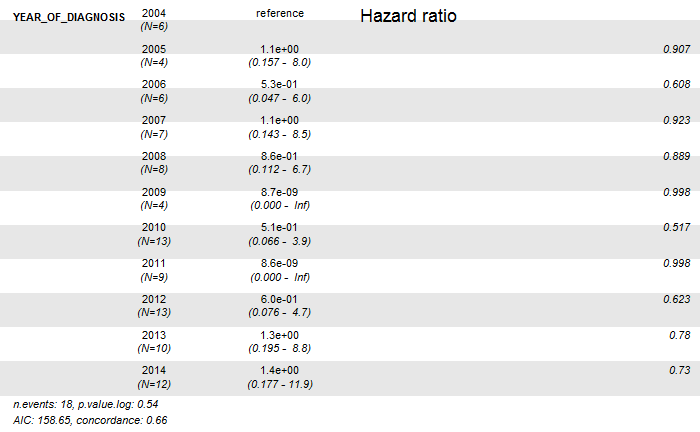

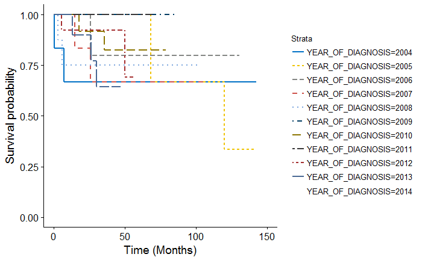

```r
uni_var(test_var = "YEAR_OF_DIAGNOSIS", data_imp = data)
```